# Calibration, Clinical Utility and Specificity of Clinical Decision Support Tools in Inflammatory Bowel Disease

Author

Dahham Alsoud

Published

July 1, 2024

Modified

July 1, 2024

The aim of this analysis notebook is to reproduce the reported analysis from the paper `Calibration, Clinical Utility and Specificity of Clinical Decision Support Tools in Inflammatory Bowel Disease`.

## Requirements:

To run the analysis, you will need:

- **Raw data files**: These should be placed inside the `input` folder within the home directory of your project. The required files are:
  - Pheno_CD_VDZ.xlsx: Excel sheet containing metadata on CD patients starting VDZ.
  - Pheno_UC_VDZ.xlsx: Excel sheet containing metadata on UC patients starting VDZ.
  - Pheno_CD_UST.xlsx: Excel sheet containing metadata on CD patients starting UST.
  - VDZ_UST_troughs.RData: R workspace containing two dataframes with trough levels of VDZ and UST.

These data files can be obtained upon reasonable request to the corresponding authors, [Séverine Vermeire](https://www.uzleuven.be/en/physicians-and-specialists/severine-vermeire), via severine.vermeire@uzleuven.be and [Bram Verstockt](https://www.uzleuven.be/nl/artsen-en-specialisten/bram-verstockt), via bram.verstockt@uzleuven.be.

- **Complementary files** deposited in the [GitHub repository](https://github.com/DahhamAlsoud/cdst-evaluation-leuven) for this analysis:
  - renv.lock, .Rprofile, renv/settings.json and renv/activate.R: These files are necessary to reproduce the same versions of the packages used in the original analysis.
  - helpers.R: This script should be sourced at the beginning of the analysis to produce some customized functions.
  - variable-selection-instability.R: This script reproduces the bootstrap analysis exploring the stability of variable selection in clinical prediction models.

## 1. Install and load needed packages/functions

```r
if (!require(pacman)) install.packages("pacman")


pacman::p_load(rio, here, magrittr, janitor, tidyverse, skimr, phdcocktail, gtsummary, survival,
               huxtable, openxlsx, ggpubr, powerjoin, rms, dcurves, epiR, pROC, glue, predRupdate)


source("helpers.R")
```

## 2. Import phenodata and pre-process input

```r
vdz_uc_starters <- import(here("input", list.files("input", pattern = "uc_vdz", ignore.case = TRUE)))
vdz_cd_starters <- import(here("input", list.files("input", pattern = "cd_vdz", ignore.case = TRUE)))
ust_cd_starters <- import(here("input", list.files("input", pattern = "cd_ust", ignore.case = TRUE)))
```

Fix excel dates

```r
important_date_vrs <- c("start_date", "visit_date", "diagnosis_date", "birth_date", "last_followup_date", "stop_date",
                        "stop_date_itt", "dose_optimisation_date", "surgery_after_date", "date_lab", "endoscopy_date")

vdz_uc_starters <- convert_date_columns(vdz_uc_starters, important_date_vrs)
vdz_cd_starters <- convert_date_columns(vdz_cd_starters, important_date_vrs)
ust_cd_starters %<>% mutate(across(where(is.POSIXct), ymd))
```

Add dates of outcomes assessment columns

```r
vdz_uc_starters <- add_assessment_dates(vdz_uc_starters)
vdz_cd_starters <- add_assessment_dates(vdz_cd_starters)
ust_cd_starters <- add_assessment_dates(ust_cd_starters)
```

Copy outcome data to the baseline row

```r
vdz_uc_starters %<>%
  group_by(patient_id) %>%
  fill(c(clinical_response_pmayo:cs_dependent_outcome, clinical_assessment_date, endoscopic_assessment_date), .direction = "up") %>%
  ungroup()

vdz_cd_starters %<>%
  group_by(patient_id) %>%
  fill(c(clinical_response:cs_dependent_outcome, clinical_assessment_date, endoscopic_assessment_date), .direction = "up") %>%
  ungroup()

ust_cd_starters %<>%
  group_by(patient_id) %>%
  fill(c(clinical_response:cs_dependent_outcome, clinical_assessment_date, endoscopic_assessment_date), .direction = "up") %>%
  ungroup()
```

Filter eligible patients

```r
vdz_uc_eligible <- vdz_uc_starters %>% filter(excluded == 0)
vdz_cd_eligible <- vdz_cd_starters %>% filter(excluded == 0)
ust_cd_eligible <- ust_cd_starters %>% filter(excluded == 0)
```

Filter included patients

```r
vdz_uc_included <- vdz_uc_eligible %>% filter(baseline_disease_activity_type != "clinical")
vdz_uc_included %<>% filter(pga > 1)
vdz_uc_included %<>% filter(clinical_assessment == 1)
vdz_uc_included %<>% filter(mes > 1, !is.na(disease_duration_yrs), !is.na(previous_antitnf), !is.na(albumin_g_L))

vdz_cd_included <- vdz_cd_eligible %>% filter(baseline_disease_activity_type != "clinical")
vdz_cd_included %<>% filter(pga > 1)
vdz_cd_included %<>% filter(clinical_assessment == 1)
vdz_cd_included %<>% filter(!is.na(intestinal_resections_before), !is.na(fistulizing_disease_prior),
                            !is.na(previous_antitnf), !is.na(albumin_g_L), !is.na(crp_mg_L))

ust_cd_included <- ust_cd_eligible %>% filter(baseline_disease_activity_type != "clinical")
ust_cd_included %<>% filter(pga > 1)
ust_cd_included %<>% filter(clinical_assessment == 1)
ust_cd_included %<>% filter(!is.na(cdst_category))
```

## 3. Get baseline characteristics (Table 1)

Identify needed columns and define new data frames

```r
tblone_vrs <- c("gender", "age_yrs", "disease_duration_yrs", "smoking", "bmi_kg_m2", "albumin_g_L","crp_mg_L", "calprotectin_ug_g",
                "concomitant_cs", "concomitant_imm", "concomitant_5asa", "previous_advancedrx_amount", "previous_antitnf",
                "intestinal_resections_before", "age_at_diagnosis_yrs",
                "disease_location", "upper_gi_disease", "disease_behaviour","peri_anal_disease", "ses_cd",
                "disease_extent", "mes",
                "fistulizing_disease_prior", "fistulizing_disease_current")

vdz_cd_tblone_df <- vdz_cd_included %>% select(any_of(tblone_vrs))
vdz_uc_tblone_df <- vdz_uc_included %>% select(any_of(tblone_vrs))
ust_cd_tblone_df <- ust_cd_included %>% select(any_of(tblone_vrs))
```

Manipulate columns

```r
continuous_vrs <- c("age_yrs", "disease_duration_yrs", "bmi_kg_m2", "albumin_g_L","crp_mg_L", "calprotectin_ug_g", "ses_cd")

vdz_cd_tblone_df %<>% mutate(across(all_of(continuous_vrs), ~ round(as.numeric(.), 1)))
ust_cd_tblone_df %<>% mutate(across(all_of(continuous_vrs), ~ round(as.numeric(.), 1)))
vdz_uc_tblone_df %<>% mutate(across(any_of(continuous_vrs), ~ round(as.numeric(.), 1)))

vdz_cd_tblone_df %<>% mutate(disease_behaviour = if_else(str_detect(disease_behaviour, "B3"), "B3", disease_behaviour))
ust_cd_tblone_df %<>% mutate(disease_behaviour = if_else(str_detect(disease_behaviour, "B3"), "B3", disease_behaviour))

ust_cd_tblone_df %<>% mutate(female_gender = if_else(gender == "F", 1, 0), .after = gender) %>% select(-gender)
vdz_cd_tblone_df %<>% mutate(female_gender = if_else(gender == "F", 1, 0), .after = gender) %>% select(-gender)
vdz_uc_tblone_df %<>% mutate(female_gender = if_else(gender == "F", 1, 0), .after = gender) %>% select(-gender)

ust_cd_tblone_df %<>% mutate(prior_smoker = if_else(smoking == 0, 0, 1), .after = smoking) %>% select(-smoking)
vdz_cd_tblone_df %<>% mutate(prior_smoker = if_else(smoking == 0, 0, 1), .after = smoking) %>% select(-smoking)
vdz_uc_tblone_df %<>% mutate(prior_smoker = if_else(smoking == 0, 0, 1), .after = smoking) %>% select(-smoking)


ust_cd_tblone_df %<>% get_age_montreal() %>% select(-age_at_diagnosis_yrs)
vdz_cd_tblone_df %<>% get_age_montreal() %>% select(-age_at_diagnosis_yrs)
vdz_uc_tblone_df %<>% get_age_montreal() %>% select(-age_at_diagnosis_yrs)


ust_cd_tblone_df %<>% recode_steroids()
vdz_cd_tblone_df %<>% recode_steroids()
vdz_uc_tblone_df %<>% recode_steroids()

ust_cd_tblone_df %<>% mutate(concomitant_imm = if_else(concomitant_imm == "0", 0, 1),
                             concomitant_5asa = if_else(concomitant_5asa == "0", 0, 1))
vdz_cd_tblone_df %<>% mutate(concomitant_imm = if_else(concomitant_imm == "0", 0, 1),
                             concomitant_5asa = if_else(concomitant_5asa == "0", 0, 1))
vdz_uc_tblone_df %<>% mutate(concomitant_imm = if_else(concomitant_imm == "0", 0, 1),
                             concomitant_5asa = if_else(concomitant_5asa == "0", 0, 1))


ust_cd_tblone_df %<>% recode_previous_advancedrx()
vdz_cd_tblone_df %<>% recode_previous_advancedrx()
vdz_uc_tblone_df %<>% recode_previous_advancedrx()


categorical_vrs <- c("concomitant_cs", "previous_advancedrx_amount", "disease_location", "disease_behaviour", "disease_extent", "mes", "age_montreal")

dichotomous_vrs <- c("female_gender", "prior_smoker", "concomitant_imm", "concomitant_5asa", "previous_antitnf", "upper_gi_disease", "peri_anal_disease",
                     "intestinal_resections_before", "fistulizing_disease_prior", "fistulizing_disease_current")
```

Recode variables to publication shape

```r
ibd_data_dict$variable_label[ibd_data_dict$variable == "ses_cd"] <- "Simple endoscopic score for CD"

ibd_data_dict %<>%
  add_row(variable = "prior_smoker", variable_label = "Prior smoking history", value = NA, value_label = NA) %>%
  add_row(variable = "intestinal_resections_before", variable_label = "Prior bowel surgery", value = NA, value_label = NA) %>%
  add_row(variable = "previous_advancedrx_amount", variable_label = "Number of previous advanced therapies", value = NA, value_label = NA) %>%
  add_row(variable = "albumin_g_L", variable_label = "Serum albumin (g/L)", value = NA, value_label = NA) %>%
  add_row(variable = "crp_mg_L", variable_label = "C-reactive protein (mg/L)", value = NA, value_label = NA) %>%
  add_row(variable = "previous_antitnf", variable_label = "Prior anti-TNF exposure", value = NA, value_label = NA) %>%
  add_row(variable = "fistulizing_disease_prior", variable_label = "Prior fistulizing disease", value = NA, value_label = NA) %>%
  add_row(variable = "fistulizing_disease_current", variable_label = "Baseline actively draining fistula", value = NA, value_label = NA)

categoricals_to_recode <- c("concomitant_cs", "disease_location", "disease_behaviour", "disease_extent", "age_montreal")

ust_cd_tblone_df$previous_advancedrx_amount <- factor(ust_cd_tblone_df$previous_advancedrx_amount, levels = c("0", "1", "2", "≥ 3"), ordered = TRUE)
vdz_cd_tblone_df$previous_advancedrx_amount <- factor(vdz_cd_tblone_df$previous_advancedrx_amount, levels = c("0", "1", "2", "≥ 3"), ordered = TRUE)
vdz_uc_tblone_df$previous_advancedrx_amount <- factor(vdz_uc_tblone_df$previous_advancedrx_amount, levels = c("0", "1", "2", "≥ 3"), ordered = TRUE)
vdz_uc_tblone_df$mes <- factor(vdz_uc_tblone_df$mes, levels = c("2", "3"), ordered = TRUE)

ust_cd_tblone_df <- recode_vrs(ust_cd_tblone_df, data_dictionary = ibd_data_dict, vrs = categoricals_to_recode, factor = TRUE)
vdz_cd_tblone_df <- recode_vrs(vdz_cd_tblone_df, data_dictionary = ibd_data_dict, vrs = categoricals_to_recode, factor = TRUE)
vdz_uc_tblone_df <- recode_vrs(vdz_uc_tblone_df, data_dictionary = ibd_data_dict, vrs = categoricals_to_recode, factor = TRUE)
```

Make the tables

```r
theme_gtsummary_journal(journal = "jama")
theme_gtsummary_compact()
```

VDZ-CD

```r
vdz_cd_tblone <- vdz_cd_tblone_df %>%
  tbl_summary(type = list(any_of(continuous_vrs) ~ "continuous",
                          any_of(categorical_vrs) ~ "categorical",
                          any_of(dichotomous_vrs) ~ "dichotomous"),
              missing_text = "missing, n",
              digits = list(all_categorical() ~ c(0, 1))) %>%
  bold_labels() %>%
  italicize_levels()

labels_to_levels <- c("upper_gi_disease", "peri_anal_disease")

tableone_body <- vdz_cd_tblone[["table_body"]]

tableone_body$row_type[tableone_body$variable %in% labels_to_levels] <- "level"

tableone_body$stat_label[tableone_body$variable %in% labels_to_levels] <- NA

tableone_body <- tableone_body[tableone_body$label != "None",]

vdz_cd_tblone[["table_body"]]  <- tableone_body
```

VDZ-UC

```r
vdz_uc_tblone <- vdz_uc_tblone_df %>%
  tbl_summary(type = list(any_of(continuous_vrs) ~ "continuous",
                          any_of(categorical_vrs) ~ "categorical",
                          any_of(dichotomous_vrs) ~ "dichotomous"),
              missing_text = "missing, n",
              digits = list(all_categorical() ~ c(0, 1))) %>%
  bold_labels() %>%
  italicize_levels()

tableone_body <- vdz_uc_tblone[["table_body"]]

tableone_body <- tableone_body[tableone_body$label != "None",]

vdz_uc_tblone[["table_body"]]  <- tableone_body
```

UST-CD

```r
ust_cd_tblone <- ust_cd_tblone_df %>%
  tbl_summary(type = list(any_of(continuous_vrs) ~ "continuous",
                          any_of(categorical_vrs) ~ "categorical",
                          any_of(dichotomous_vrs) ~ "dichotomous"),
              missing_text = "missing, n",
              digits = list(all_categorical() ~ c(0, 1))) %>%
  bold_labels() %>%
  italicize_levels()

tableone_body <- ust_cd_tblone[["table_body"]]

tableone_body$row_type[tableone_body$variable %in% labels_to_levels] <- "level"

tableone_body$stat_label[tableone_body$variable %in% labels_to_levels] <- NA

tableone_body <- tableone_body[tableone_body$label != "None",]

ust_cd_tblone[["table_body"]]  <- tableone_body
```

Merge the tables

```r
tbl_merge(
    tbls = list(vdz_cd_tblone, vdz_uc_tblone, ust_cd_tblone),
    tab_spanner = c("**VDZ-CD**", "**VDZ-UC**", "**UST-CD**")
  )
```

| **Characteristic** | **VDZ-CD** **N = 280** | **VDZ-UC** **N = 218** | **UST-CD** **N = 194** |
| --- | --- | --- | --- |
| Female, n (%) | 170 (60.7) | 118 (54.1) | 121 (62.4) |
| Age (year), Median (IQR) | 41 (29 – 55) | 41 (29 – 53) | 41 (30 – 56) |
| Disease duration (year), Median (IQR) | 11 (4 – 22) | 8 (2 – 14) | 13 (6 – 24) |
| Prior smoking history, n (%) | 134 (47.9) | 66 (30.3) | 91 (46.9) |
| Body mass index (kg/m²), Median (IQR) | 23.8 (21.3 – 27.1) | 23.8 (20.7 – 27.3) | 23.4 (20.6 – 26.9) |
| Serum albumin (g/L), Median (IQR) | 41.9 (39.2 – 44.1) | 42.0 (39.4 – 44.7) | 41.2 (38.9 – 43.3) |
| C-reactive protein (mg/L), Median (IQR) | 5 (2 – 14) | 3 (1 – 8) | 8 (3 – 19) |
| Faecal calprotectin (ug/g), Median (IQR) | 649 (271 – 1,800) | 1,673 (665 – 1,800) | 985 (405 – 1,800) |
| missing, n | 159 | 125 | 50 |
| Concomitant corticosteroids, n (%) |  |  |  |
| Topical | 37 (13.2) | 77 (35.3) | 12 (6.2) |
| Systemic | 34 (12.1) | 35 (16.1) | 13 (6.7) |
| Concomitant immunomodulators, n (%) | 14 (5.0) | 7 (3.2) | 0 (0.0) |
| Concomitant 5-aminosalicylates, n (%) | 4 (1.4) | 112 (51.4) | 0 (0.0) |
| Number of previous advanced therapies, n (%) |  |  |  |
| 0 | 72 (25.7) | 82 (37.6) | 39 (20.1) |
| 1 | 81 (28.9) | 78 (35.8) | 38 (19.6) |
| 2 | 104 (37.1) | 50 (22.9) | 54 (27.8) |
| ≥ 3 | 23 (8.2) | 8 (3.7) | 63 (32.5) |
| Prior anti-TNF exposure, n (%) | 204 (72.9) | 136 (62.4) | 151 (77.8) |
| Prior bowel surgery, n (%) | 131 (46.8) | 0 (0.0) | 96 (49.5) |
| Age at diagnosis (year), n (%) |  |  |  |
| < 17 years | 42 (15.0) | 21 (9.6) | 27 (13.9) |
| 17-40 years | 190 (67.9) | 132 (60.6) | 139 (71.6) |
| > 40 years | 48 (17.1) | 65 (29.8) | 28 (14.4) |
| Disease location, n (%) |  |  |  |
| Ileal | 81 (28.9) |  | 60 (30.9) |
| Colonic | 41 (14.6) |  | 22 (11.3) |
| Ileocolonic | 158 (56.4) |  | 112 (57.7) |
| Upper GI modifier | 19 (6.8) |  | 18 (9.3) |
| Disease behaviour, n (%) |  |  |  |
| Inflammatory | 109 (38.9) |  | 78 (40.2) |
| Fibrostenotic | 110 (39.3) |  | 73 (37.6) |
| Penetrating | 61 (21.8) |  | 43 (22.2) |
| Perianal modifier | 86 (30.7) |  | 69 (35.6) |
| Simple endoscopic score for CD, Median (IQR) | 7.5 (5.0 – 15.0) |  | 10 (6 – 16) |
| missing, n | 184 |  | 40 |
| Prior fistulizing disease, n (%) | 95 (33.9) |  | 70 (36.1) |
| Baseline actively draining fistula, n (%) | 14 (5.0) |  | 9 (4.6) |
| Disease extent |  |  |  |
| Proctitis |  | 18 (8.3) |  |
| Left-sided colitis |  | 115 (52.8) |  |
| Extensive colitis |  | 85 (39.0) |  |
| Mayo endoscopic subscore |  |  |  |
| 2 |  | 98 (45.0) |  |
| 3 |  | 120 (55.0) |  |

## 4. Calculate CDST points and assign response categories

### VDZ-UC

Ensure that we have all CDST variables in numeric shape ready for calculations

```r
vdz_uc_included %<>% mutate(no_previous_antitnf = if_else(previous_antitnf == 1, 0, 1), .after = previous_antitnf)

is.numeric(vdz_uc_included$no_previous_antitnf)
```

```
[1] TRUE
```

```r
is.numeric(vdz_uc_included$albumin_g_L)
```

```
[1] TRUE
```

```r
vdz_uc_included %<>% mutate(moderate_endo_activity = if_else(mes == 2, 1, 0), .after = mes)

is.numeric(vdz_uc_included$moderate_endo_activity)
```

```
[1] TRUE
```

```r
vdz_uc_included %<>% mutate(dxduration_above_two = if_else(disease_duration_yrs >= 2, 1, 0), .after = disease_duration_yrs)

is.numeric(vdz_uc_included$dxduration_above_two)
```

```
[1] TRUE
```

Calculate CDST points

```r
vdz_uc_included %<>% mutate(cdst_points = 3*dxduration_above_two + 3*no_previous_antitnf + 2*moderate_endo_activity + 0.65*albumin_g_L)
```

Assign CDST categories

```r
vdz_uc_included %<>% mutate(cdst_category = case_when(cdst_points <= 26 ~ "Low",
                                                      cdst_points > 26 & cdst_points <= 32 ~ "Intermediate",
                                                      cdst_points > 32 ~ "High")
)

vdz_uc_included %>% count(cdst_category)
```

| cdst_category | n |
| --- | --- |
| High | 95 |
| Intermediate | 105 |
| Low | 18 |

```r
vdz_uc_included$cdst_category <- factor(vdz_uc_included$cdst_category, levels = c("Low", "Intermediate", "High"), ordered = TRUE)
```

### VDZ-CD

Ensure that we have all CDST variables in numeric shape ready for calculations

```r
vdz_cd_included %<>% mutate(no_previous_antitnf = if_else(previous_antitnf == 1, 0, 1), .after = previous_antitnf)

is.numeric(vdz_cd_included$no_previous_antitnf)
```

```
[1] TRUE
```

```r
vdz_cd_included %<>% mutate(no_surgery_before = if_else(intestinal_resections_before == 1, 0, 1), .after = intestinal_resections_before)

is.numeric(vdz_cd_included$no_surgery_before)
```

```
[1] TRUE
```

```r
vdz_cd_included %<>% mutate(no_fistulizing_before = if_else(fistulizing_disease_prior == 1, 0, 1), .after = fistulizing_disease_prior)

is.numeric(vdz_cd_included$no_fistulizing_before)
```

```
[1] TRUE
```

```r
is.numeric(vdz_cd_included$albumin_g_L)
```

```
[1] TRUE
```

```r
is.numeric(vdz_cd_included$crp_mg_L)
```

```
[1] TRUE
```

Calculate CDST points

```r
vdz_cd_included %<>% mutate(cdst_points = 2*no_surgery_before + 3*no_previous_antitnf + 2*no_fistulizing_before + 0.4*albumin_g_L - case_when(crp_mg_L >= 3 & crp_mg_L <= 10 ~ 0.5,
                                                                                                                                              crp_mg_L > 10 ~ 3,
                                                                                                                                              .default = 0))
```

Assign CDST categories

```r
vdz_cd_included %<>% mutate(cdst_category = case_when(cdst_points <= 13 ~ "Low",
                                                      cdst_points > 13 & cdst_points <= 19 ~ "Intermediate",
                                                      cdst_points > 19 ~ "High")
)

vdz_cd_included %>% count(cdst_category)
```

| cdst_category | n |
| --- | --- |
| High | 121 |
| Intermediate | 146 |
| Low | 13 |

```r
vdz_cd_included$cdst_category <- factor(vdz_cd_included$cdst_category, levels = c("Low", "Intermediate", "High"), ordered = TRUE)
```

### UST-CD

```r
ust_cd_included %>% count(cdst_category)
```

| cdst_category | n |
| --- | --- |
| High | 80 |
| Intermediate | 95 |
| Low | 19 |

```r
ust_cd_included$cdst_category <- factor(ust_cd_included$cdst_category, levels = c("Low", "Intermediate", "High"), ordered = TRUE)
```

## 5. Calculate discrimination for effectiveness outcomes

### VDZ-CD

Clinical response

```r
vdz_cd_included %<>% mutate(clinical_assessment_before_optimisation = clinical_assessment_date <= dose_optimisation_date) %>%
  replace_na(list(clinical_assessment_before_optimisation = TRUE))

vdz_cd_included %<>% mutate(clinical_response_cdst = clinical_response == 1 & clinical_assessment_before_optimisation)

vdz_cd_included %>% count(cdst_category, clinical_response_cdst)
```

| cdst_category | clinical_response_cdst | n |
| --- | --- | --- |
| Low | FALSE | 7 |
| Low | TRUE | 6 |
| Intermediate | FALSE | 64 |
| Intermediate | TRUE | 82 |
| High | FALSE | 31 |
| High | TRUE | 90 |

```r
options(scipen = 999)

chisq_vdz_cd_clinical_response <- chisq.test(vdz_cd_included$cdst_category, vdz_cd_included$clinical_response_cdst)

vdz_cd_cdst_tabulation_clinical_response <- vdz_cd_included %>%
  group_by(cdst_category) %>%
  summarise(total = n(),
            achieved = sum(clinical_response_cdst),
            percentage = scales::percent(achieved/total))
```

Clinical remission

```r
vdz_cd_included %<>% mutate(clinical_remission_cdst = clinical_remission == 1 & clinical_assessment_before_optimisation)

vdz_cd_included %>% count(cdst_category, clinical_remission_cdst)
```

| cdst_category | clinical_remission_cdst | n |
| --- | --- | --- |
| Low | FALSE | 13 |
| Intermediate | FALSE | 126 |
| Intermediate | TRUE | 20 |
| High | FALSE | 96 |
| High | TRUE | 25 |

```r
chisq_vdz_cd_clinical_remission <- chisq.test(vdz_cd_included$cdst_category, vdz_cd_included$clinical_remission_cdst)

vdz_cd_cdst_tabulation_clinical_remission <- vdz_cd_included %>%
  group_by(cdst_category) %>%
  summarise(total = n(),
            achieved = sum(clinical_remission_cdst),
            percentage = scales::percent(achieved/total))
```

Endoscopic response

```r
vdz_cd_included_endoscopic <- vdz_cd_included %>%
  filter(endoscopic_assessment == 1)

vdz_cd_included_endoscopic %<>% mutate(endoscopic_assessment_before_optimisation = endoscopic_assessment_date <= dose_optimisation_date) %>%
  replace_na(list(endoscopic_assessment_before_optimisation = TRUE))

vdz_cd_included_endoscopic %<>% mutate(endoscopic_response_cdst = endoscopic_response == 1 & endoscopic_assessment_before_optimisation)


vdz_cd_included_endoscopic %>% count(cdst_category, endoscopic_response_cdst)
```

| cdst_category | endoscopic_response_cdst | n |
| --- | --- | --- |
| Low | FALSE | 8 |
| Low | TRUE | 2 |
| Intermediate | FALSE | 51 |
| Intermediate | TRUE | 53 |
| High | FALSE | 33 |
| High | TRUE | 66 |

```r
chisq_vdz_cd_endoscopic_response <- chisq.test(vdz_cd_included_endoscopic$cdst_category, vdz_cd_included_endoscopic$endoscopic_response_cdst)

vdz_cd_cdst_tabulation_endoscopic_response <- vdz_cd_included_endoscopic %>%
  group_by(cdst_category) %>%
  summarise(total = n(),
            achieved = sum(endoscopic_response_cdst),
            percentage = scales::percent(achieved/total))
```

Endoscopic remission

```r
vdz_cd_included_endoscopic %<>% mutate(endoscopic_remission_cdst = endoscopic_remission == 1 & endoscopic_assessment_before_optimisation)

vdz_cd_included_endoscopic %>% count(cdst_category, endoscopic_remission_cdst)
```

| cdst_category | endoscopic_remission_cdst | n |
| --- | --- | --- |
| Low | FALSE | 9 |
| Low | TRUE | 1 |
| Intermediate | FALSE | 84 |
| Intermediate | TRUE | 20 |
| High | FALSE | 57 |
| High | TRUE | 42 |

```r
chisq_vdz_cd_endoscopic_remission <- chisq.test(vdz_cd_included_endoscopic$cdst_category, vdz_cd_included_endoscopic$endoscopic_remission_cdst)

vdz_cd_cdst_tabulation_endoscopic_remission <- vdz_cd_included_endoscopic %>%
  group_by(cdst_category) %>%
  summarise(total = n(),
            achieved = sum(endoscopic_remission_cdst),
           percentage = scales::percent(achieved/total))
```

### VDZ-UC

Clinical response

```r
vdz_uc_included %<>% mutate(clinical_assessment_before_optimisation = clinical_assessment_date <= dose_optimisation_date) %>%
  replace_na(list(clinical_assessment_before_optimisation = TRUE))

vdz_uc_included %<>% mutate(clinical_response_cdst = clinical_response_pga == 1 & clinical_assessment_before_optimisation)

vdz_uc_included %>% count(cdst_category, clinical_response_cdst)
```

| cdst_category | clinical_response_cdst | n |
| --- | --- | --- |
| Low | FALSE | 9 |
| Low | TRUE | 9 |
| Intermediate | FALSE | 47 |
| Intermediate | TRUE | 58 |
| High | FALSE | 20 |
| High | TRUE | 75 |

```r
chisq_vdz_uc_clinical_response <- chisq.test(vdz_uc_included$cdst_category, vdz_uc_included$clinical_response_cdst)

vdz_uc_cdst_tabulation_clinical_response <- vdz_uc_included %>%
  group_by(cdst_category) %>%
  summarise(total = n(),
            achieved = sum(clinical_response_cdst),
            percentage = scales::percent(achieved/total))
```

Clinical remission

```r
vdz_uc_included %<>% mutate(clinical_remission_cdst = clinical_remission_pga == 1 & clinical_assessment_before_optimisation)

vdz_uc_included %>% count(cdst_category, clinical_remission_cdst)
```

| cdst_category | clinical_remission_cdst | n |
| --- | --- | --- |
| Low | FALSE | 15 |
| Low | TRUE | 3 |
| Intermediate | FALSE | 90 |
| Intermediate | TRUE | 15 |
| High | FALSE | 62 |
| High | TRUE | 33 |

```r
chisq_vdz_uc_clinical_remission <- chisq.test(vdz_uc_included$cdst_category, vdz_uc_included$clinical_remission_cdst)

vdz_uc_cdst_tabulation_clinical_remission <- vdz_uc_included %>%
  group_by(cdst_category) %>%
  summarise(total = n(),
            achieved = sum(clinical_remission_cdst),
            percentage = scales::percent(achieved/total))
```

Endoscopic response

```r
vdz_uc_included_endoscopic <- vdz_uc_included %>%
  filter(endoscopic_assessment == 1)

vdz_uc_included_endoscopic %<>% mutate(endoscopic_assessment_before_optimisation = endoscopic_assessment_date <= dose_optimisation_date) %>%
  replace_na(list(endoscopic_assessment_before_optimisation = TRUE))

vdz_uc_included_endoscopic %<>% mutate(endoscopic_response_cdst = endoscopic_response == 1 & endoscopic_assessment_before_optimisation)

vdz_uc_included_endoscopic %>% count(cdst_category, endoscopic_response_cdst)
```

| cdst_category | endoscopic_response_cdst | n |
| --- | --- | --- |
| Low | FALSE | 10 |
| Low | TRUE | 8 |
| Intermediate | FALSE | 63 |
| Intermediate | TRUE | 42 |
| High | FALSE | 26 |
| High | TRUE | 68 |

```r
chisq_vdz_uc_endoscopic_response <- chisq.test(vdz_uc_included_endoscopic$cdst_category, vdz_uc_included_endoscopic$endoscopic_response_cdst)

vdz_uc_cdst_tabulation_endoscopic_response <- vdz_uc_included_endoscopic %>%
  group_by(cdst_category) %>%
  summarise(total = n(),
            achieved = sum(endoscopic_response_cdst),
            percentage = scales::percent(achieved/total))
```

Endoscopic remission

```r
vdz_uc_included_endoscopic %<>% mutate(endoscopic_remission_cdst = endoscopic_remission == 1 & endoscopic_assessment_before_optimisation)

vdz_uc_included_endoscopic %>% count(cdst_category, endoscopic_remission_cdst)
```

| cdst_category | endoscopic_remission_cdst | n |
| --- | --- | --- |
| Low | FALSE | 11 |
| Low | TRUE | 7 |
| Intermediate | FALSE | 79 |
| Intermediate | TRUE | 26 |
| High | FALSE | 53 |
| High | TRUE | 41 |

```r
chisq_vdz_uc_endoscopic_remission <- chisq.test(vdz_uc_included_endoscopic$cdst_category, vdz_uc_included_endoscopic$endoscopic_remission_cdst)

vdz_uc_cdst_tabulation_endoscopic_remission <- vdz_uc_included_endoscopic %>%
  group_by(cdst_category) %>%
  summarise(total = n(),
            achieved = sum(endoscopic_remission_cdst),
            percentage = scales::percent(achieved/total))
```

### UST-CD

Clinical response

```r
ust_cd_included %<>% mutate(clinical_assessment_before_optimisation = clinical_assessment_date <= first_dose_optimisation_date) %>%
  replace_na(list(clinical_assessment_before_optimisation = TRUE))

ust_cd_included %<>% mutate(clinical_response_cdst = clinical_response == 1 & clinical_assessment_before_optimisation)

ust_cd_included %>% count(cdst_category, clinical_response_cdst)
```

| cdst_category | clinical_response_cdst | n |
| --- | --- | --- |
| Low | FALSE | 4 |
| Low | TRUE | 15 |
| Intermediate | FALSE | 45 |
| Intermediate | TRUE | 50 |
| High | FALSE | 31 |
| High | TRUE | 49 |

```r
chisq_ust_cd_clinical_response <- chisq.test(ust_cd_included$cdst_category, ust_cd_included$clinical_response_cdst)

ust_cd_cdst_tabulation_clinical_response <- ust_cd_included %>%
  group_by(cdst_category) %>%
  summarise(total = n(),
            achieved = sum(clinical_response_cdst),
            percentage = scales::percent(achieved/total))
```

Clinical remission

```r
ust_cd_included %<>% mutate(clinical_remission_cdst = clinical_remission == 1 & clinical_assessment_before_optimisation)

ust_cd_included %>% count(cdst_category, clinical_remission_cdst)
```

| cdst_category | clinical_remission_cdst | n |
| --- | --- | --- |
| Low | FALSE | 16 |
| Low | TRUE | 3 |
| Intermediate | FALSE | 86 |
| Intermediate | TRUE | 9 |
| High | FALSE | 61 |
| High | TRUE | 19 |

```r
chisq_ust_cd_clinical_remission <- chisq.test(ust_cd_included$cdst_category, ust_cd_included$clinical_remission_cdst)

ust_cd_cdst_tabulation_clinical_remission <- ust_cd_included %>%
  group_by(cdst_category) %>%
  summarise(total = n(),
            achieved = sum(clinical_remission_cdst),
            percentage = scales::percent(achieved/total))
```

Endoscopic response

```r
ust_cd_included_endoscopic <- ust_cd_included %>%
  filter(endoscopic_assessment == 1)

ust_cd_included_endoscopic %<>% mutate(endoscopic_assessment_before_optimisation = endoscopic_assessment_date <= first_dose_optimisation_date) %>%
  replace_na(list(endoscopic_assessment_before_optimisation = TRUE))

ust_cd_included_endoscopic %<>% mutate(endoscopic_response_cdst = endoscopic_response == 1 & endoscopic_assessment_before_optimisation)


ust_cd_included_endoscopic %>% count(cdst_category, endoscopic_response_cdst)
```

| cdst_category | endoscopic_response_cdst | n |
| --- | --- | --- |
| Low | FALSE | 6 |
| Low | TRUE | 11 |
| Intermediate | FALSE | 39 |
| Intermediate | TRUE | 42 |
| High | FALSE | 33 |
| High | TRUE | 35 |

```r
chisq_ust_cd_endoscopic_response <- chisq.test(ust_cd_included_endoscopic$cdst_category, ust_cd_included_endoscopic$endoscopic_response_cdst)

ust_cd_cdst_tabulation_endoscopic_response <- ust_cd_included_endoscopic %>%
  group_by(cdst_category) %>%
  summarise(total = n(),
            achieved = sum(endoscopic_response_cdst),
            percentage = scales::percent(achieved/total))
```

Endoscopic remission

```r
ust_cd_included_endoscopic %<>% mutate(endoscopic_remission_cdst = endoscopic_remission == 1 & endoscopic_assessment_before_optimisation)

ust_cd_included_endoscopic %>% count(cdst_category, endoscopic_remission_cdst)
```

| cdst_category | endoscopic_remission_cdst | n |
| --- | --- | --- |
| Low | FALSE | 15 |
| Low | TRUE | 2 |
| Intermediate | FALSE | 74 |
| Intermediate | TRUE | 7 |
| High | FALSE | 54 |
| High | TRUE | 14 |

```r
chisq_ust_cd_endoscopic_remission <- chisq.test(ust_cd_included_endoscopic$cdst_category, ust_cd_included_endoscopic$endoscopic_remission_cdst)

ust_cd_cdst_tabulation_endoscopic_remission <- ust_cd_included_endoscopic %>%
  group_by(cdst_category) %>%
  summarise(total = n(),
            achieved = sum(endoscopic_remission_cdst),
            percentage = scales::percent(achieved/total))
```

## 6. Visualize discrimination for effectiveness outcomes

### VDZ-CD

```r
vdz_cd_clinical_response_gg <- ggplot(data = vdz_cd_included, aes(x = cdst_category, fill = clinical_response_cdst)) +
  geom_bar() +
  scale_y_continuous(limits = c(0, 160), breaks = seq(0, 160, 20)) +
  scale_fill_manual(values = c("#D55E00", "#999999"), labels = c("yes", "no"), breaks = c(TRUE, FALSE)) +
  coord_cartesian(expand = 0) +
  labs(y = "Number of patients", title = "Clinical response") +
  theme(axis.ticks = element_blank(),
        panel.background = element_blank(),
        axis.title = element_text(face = "bold", size = 13),
        axis.title.x = element_blank(),
        axis.text = element_text(face = "bold"),
        legend.position = "none",
        plot.title = element_text(hjust = 0.5, face = "bold", size = 13)) +
  annotate(geom = "text", label = paste0(vdz_cd_cdst_tabulation_clinical_response$percentage, "\n", "(", vdz_cd_cdst_tabulation_clinical_response$achieved, "/", vdz_cd_cdst_tabulation_clinical_response$total, ")"),
           x = 1:3, y = vdz_cd_cdst_tabulation_clinical_response$achieved + 7,
           size = 3, fontface = "bold") +
  annotate(geom = "text", label = format_p_value(chisq_vdz_cd_clinical_response$p.value), x = 2, y = 158.5, size = 4, fontface = "bold")

vdz_cd_clinical_remission_gg <- ggplot(data = vdz_cd_included, aes(x = cdst_category, fill = clinical_remission_cdst)) +
  geom_bar() +
  scale_y_continuous(limits = c(0, 160), breaks = seq(0, 160, 20)) +
  scale_fill_manual(values = c("#D55E00", "#999999"), labels = c("yes", "no"), breaks = c(TRUE, FALSE)) +
  coord_cartesian(expand = 0) +
  labs(y = "Number of patients", title = "Clinical remission") +
  theme(axis.ticks = element_blank(),
        panel.background = element_blank(),
        axis.title = element_text(face = "bold"),
        axis.title.x = element_blank(),
        axis.title.y = element_blank(),
        axis.text = element_text(face = "bold"),
        legend.position = "none",
        plot.title = element_text(hjust = 0.5, face = "bold", size = 13)) +
  annotate(geom = "text", label = paste0(vdz_cd_cdst_tabulation_clinical_remission$percentage, "\n", "(", vdz_cd_cdst_tabulation_clinical_remission$achieved, "/", vdz_cd_cdst_tabulation_clinical_remission$total, ")"),
           x = 1:3, y = vdz_cd_cdst_tabulation_clinical_remission$achieved + 7,
           size = 3, fontface = "bold") +
  annotate(geom = "text", label = format_p_value(chisq_vdz_cd_clinical_remission$p.value), x = 2, y = 158.5, size = 4, fontface = "bold")

vdz_cd_endoscopic_response_gg <- ggplot(data = vdz_cd_included_endoscopic, aes(x = cdst_category, fill = endoscopic_response_cdst)) +
  geom_bar() +
  scale_y_continuous(limits = c(0, 120), breaks = seq(0, 120, 20)) +
  scale_fill_manual(values = c("#D55E00", "#999999"), labels = c("yes", "no"), breaks = c(TRUE, FALSE)) +
  coord_cartesian(expand = 0) +
  labs(y = "Number of patients", title = "Endoscopic response") +
  theme(axis.ticks = element_blank(),
        panel.background = element_blank(),
        axis.title = element_text(face = "bold", size = 13),
        plot.title = element_text(hjust = 0.5, face = "bold", size = 13),
        axis.text = element_text(face = "bold"),
        axis.title.x = element_blank(),
        legend.position = "none") +
  annotate(geom = "text", label = paste0(vdz_cd_cdst_tabulation_endoscopic_response$percentage, "\n", "(", vdz_cd_cdst_tabulation_endoscopic_response$achieved, "/", vdz_cd_cdst_tabulation_endoscopic_response$total, ")"),
           x = 1:3, y = vdz_cd_cdst_tabulation_endoscopic_response$achieved + 5,
           size = 3, fontface = "bold") +
  annotate(geom = "text", label = format_p_value(chisq_vdz_cd_endoscopic_response$p.value), x = 2, y = 118.5, size = 4, fontface = "bold")

vdz_cd_endoscopic_remission_gg <- ggplot(data = vdz_cd_included_endoscopic, aes(x = cdst_category, fill = endoscopic_remission_cdst)) +
  geom_bar() +
  scale_y_continuous(limits = c(0, 120), breaks = seq(0, 120, 20)) +
  scale_fill_manual(values = c("#D55E00", "#999999"), labels = c("yes", "no"), breaks = c(TRUE, FALSE)) +
  coord_cartesian(expand = 0) +
  labs(title = "Endoscopic remission") +
  theme(axis.ticks = element_blank(),
        panel.background = element_blank(),
        axis.title = element_text(face = "bold"),
        axis.text = element_text(face = "bold"),
        axis.title.x = element_blank(),
        axis.title.y = element_blank(),
        legend.position = "none",
        plot.title = element_text(hjust = 0.5, face = "bold", size = 13)) +
  annotate(geom = "text", label = paste0(vdz_cd_cdst_tabulation_endoscopic_remission$percentage, "\n", "(", vdz_cd_cdst_tabulation_endoscopic_remission$achieved, "/", vdz_cd_cdst_tabulation_endoscopic_remission$total, ")"),
           x = 1:3, y = vdz_cd_cdst_tabulation_endoscopic_remission$achieved + 5,
           size = 3, fontface = "bold") +
  annotate(geom = "text", label = format_p_value(chisq_vdz_cd_endoscopic_remission$p.value), x = 2, y = 118.5, size = 4, fontface = "bold")
```

Combine figures in 4 panels

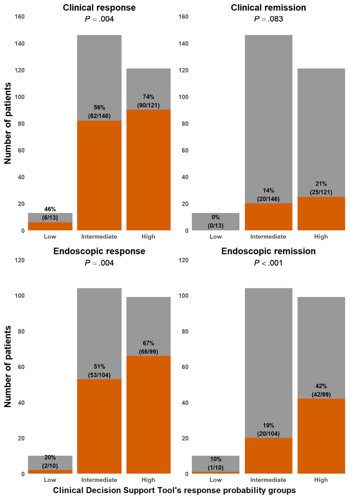

```r
vdz_cd_bars_combined <- ggarrange(vdz_cd_clinical_response_gg, vdz_cd_clinical_remission_gg, vdz_cd_endoscopic_response_gg, vdz_cd_endoscopic_remission_gg, nrow = 2, ncol = 2)

annotate_figure(vdz_cd_bars_combined, bottom = text_grob("Clinical Decision Support Tool's response probability groups", face = "bold", vjust = 0.1))
```

### VDZ-UC

```r
vdz_uc_clinical_response_gg <- ggplot(data = vdz_uc_included, aes(x = cdst_category, fill = clinical_response_cdst)) +
  geom_bar() +
  scale_y_continuous(limits = c(0, 120), breaks = seq(0, 120, 20)) +
  scale_fill_manual(values = c("#D55E00", "#999999"), labels = c("yes", "no"), breaks = c(TRUE, FALSE)) +
  coord_cartesian(expand = 0) +
  labs(y = "Number of patients", title = "Clinical response") +
  theme(axis.ticks = element_blank(),
        panel.background = element_blank(),
        axis.title = element_text(face = "bold", size = 13),
        axis.title.x = element_blank(),
        axis.text = element_text(face = "bold"),
        legend.position = "none",
        plot.title = element_text(hjust = 0.5, face = "bold", size = 13)) +
  annotate(geom = "text", label = paste0(vdz_uc_cdst_tabulation_clinical_response$percentage, "\n", "(", vdz_uc_cdst_tabulation_clinical_response$achieved, "/", vdz_uc_cdst_tabulation_clinical_response$total, ")"),
           x = 1:3, y = vdz_uc_cdst_tabulation_clinical_response$achieved + 5,
           size = 3, fontface = "bold") +
  annotate(geom = "text", label = format_p_value(chisq_vdz_uc_clinical_response$p.value), x = 2, y = 118.5, size = 4, fontface = "bold")

vdz_uc_clinical_remission_gg <- ggplot(data = vdz_uc_included, aes(x = cdst_category, fill = clinical_remission_cdst)) +
  geom_bar() +
  scale_y_continuous(limits = c(0, 120), breaks = seq(0, 120, 20)) +
  scale_fill_manual(values = c("#D55E00", "#999999"), labels = c("yes", "no"), breaks = c(TRUE, FALSE)) +
  coord_cartesian(expand = 0) +
  labs(y = "Number of patients", title = "Clinical remission") +
  theme(axis.ticks = element_blank(),
        panel.background = element_blank(),
        axis.title = element_text(face = "bold"),
        axis.title.x = element_blank(),
        axis.title.y = element_blank(),
        axis.text = element_text(face = "bold"),
        legend.position = "none",
        plot.title = element_text(hjust = 0.5, face = "bold", size = 13)) +
  annotate(geom = "text", label = paste0(vdz_uc_cdst_tabulation_clinical_remission$percentage, "\n", "(", vdz_uc_cdst_tabulation_clinical_remission$achieved, "/", vdz_uc_cdst_tabulation_clinical_remission$total, ")"),
           x = 1:3, y = vdz_uc_cdst_tabulation_clinical_remission$achieved + 5,
           size = 3, fontface = "bold") +
  annotate(geom = "text", label = format_p_value(chisq_vdz_uc_clinical_remission$p.value), x = 2, y = 118.5, size = 4, fontface = "bold")

vdz_uc_endoscopic_response_gg <- ggplot(data = vdz_uc_included_endoscopic, aes(x = cdst_category, fill = endoscopic_response_cdst)) +
  geom_bar() +
  scale_y_continuous(limits = c(0, 120), breaks = seq(0, 120, 20)) +
  scale_fill_manual(values = c("#D55E00", "#999999"), labels = c("yes", "no"), breaks = c(TRUE, FALSE)) +
  coord_cartesian(expand = 0) +
  labs(y = "Number of patients", title = "Endoscopic response") +
  theme(axis.ticks = element_blank(),
        panel.background = element_blank(),
        axis.title = element_text(face = "bold", size = 13),
        plot.title = element_text(hjust = 0.5, face = "bold", size = 13),
        axis.text = element_text(face = "bold"),
        axis.title.x = element_blank(),
        legend.position = "none") +
  annotate(geom = "text", label = paste0(vdz_uc_cdst_tabulation_endoscopic_response$percentage, "\n", "(", vdz_uc_cdst_tabulation_endoscopic_response$achieved, "/", vdz_uc_cdst_tabulation_endoscopic_response$total, ")"),
           x = 1:3, y = vdz_uc_cdst_tabulation_endoscopic_response$achieved + 5,
           size = 3, fontface = "bold") +
  annotate(geom = "text", label = format_p_value(chisq_vdz_uc_endoscopic_response$p.value), x = 2, y = 118.5, size = 4, fontface = "bold")

vdz_uc_endoscopic_remission_gg <- ggplot(data = vdz_uc_included_endoscopic, aes(x = cdst_category, fill = endoscopic_remission_cdst)) +
  geom_bar() +
  scale_y_continuous(limits = c(0, 120), breaks = seq(0, 120, 20)) +
  scale_fill_manual(values = c("#D55E00", "#999999"), labels = c("yes", "no"), breaks = c(TRUE, FALSE)) +
  coord_cartesian(expand = 0) +
  labs(title = "Endoscopic remission") +
  theme(axis.ticks = element_blank(),
        panel.background = element_blank(),
        axis.title = element_text(face = "bold"),
        axis.text = element_text(face = "bold"),
        axis.title.x = element_blank(),
        axis.title.y = element_blank(),
        legend.position = "none",
        plot.title = element_text(hjust = 0.5, face = "bold", size = 13)) +
  annotate(geom = "text", label = paste0(vdz_uc_cdst_tabulation_endoscopic_remission$percentage, "\n", "(", vdz_uc_cdst_tabulation_endoscopic_remission$achieved, "/", vdz_uc_cdst_tabulation_endoscopic_remission$total, ")"),
           x = 1:3, y = vdz_uc_cdst_tabulation_endoscopic_remission$achieved + 5,
           size = 3, fontface = "bold") +
  annotate(geom = "text", label = format_p_value(chisq_vdz_uc_endoscopic_remission$p.value), x = 2, y = 118.5, size = 4, fontface = "bold")
```

Combine figures in 4 panels

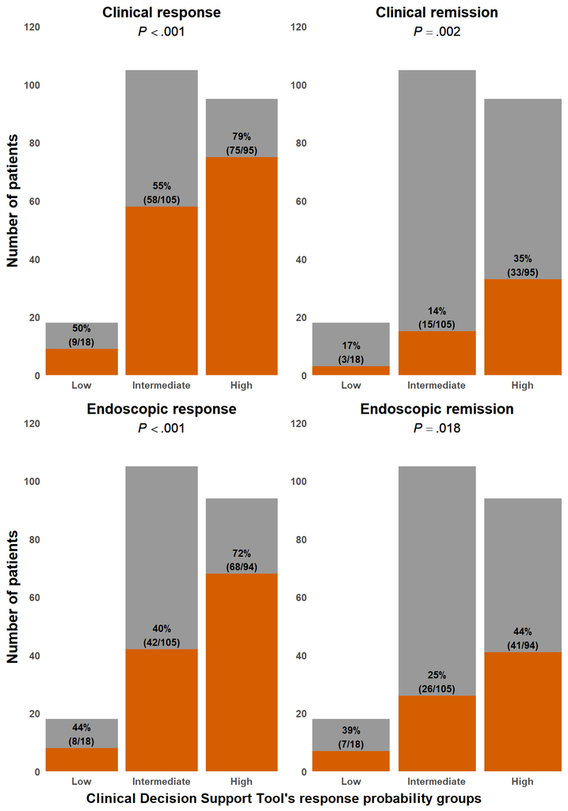

```r
vdz_uc_bars_combined <- ggarrange(vdz_uc_clinical_response_gg, vdz_uc_clinical_remission_gg, vdz_uc_endoscopic_response_gg, vdz_uc_endoscopic_remission_gg, nrow = 2, ncol = 2)

annotate_figure(vdz_uc_bars_combined, bottom = text_grob("Clinical Decision Support Tool's response probability groups", face = "bold", vjust = 0.1))
```

### UST-CD

```r
ust_cd_clinical_response_gg <- ggplot(data = ust_cd_included, aes(x = cdst_category, fill = clinical_response_cdst)) +
  geom_bar() +
  scale_y_continuous(limits = c(0, 120), breaks = seq(0, 120, 20)) +
  scale_fill_manual(values = c("#D55E00", "#999999"), labels = c("yes", "no"), breaks = c(TRUE, FALSE)) +
  coord_cartesian(expand = 0) +
  labs(y = "Number of patients", title = "Clinical response") +
  theme(axis.ticks = element_blank(),
        panel.background = element_blank(),
        axis.title = element_text(face = "bold", size = 13),
        axis.title.x = element_blank(),
        axis.text = element_text(face = "bold"),
        legend.position = "none",
        plot.title = element_text(hjust = 0.5, face = "bold", size = 13)) +
  annotate(geom = "text", label = paste0(ust_cd_cdst_tabulation_clinical_response$percentage, "\n", "(", ust_cd_cdst_tabulation_clinical_response$achieved, "/", ust_cd_cdst_tabulation_clinical_response$total, ")"),
           x = 1:3, y = ust_cd_cdst_tabulation_clinical_response$achieved + 5,
           size = 3, fontface = "bold") +
  annotate(geom = "text", label = format_p_value(chisq_ust_cd_clinical_response$p.value), x = 2, y = 118.5, size = 4, fontface = "bold")

ust_cd_clinical_remission_gg <- ggplot(data = ust_cd_included, aes(x = cdst_category, fill = clinical_remission_cdst)) +
  geom_bar() +
  scale_y_continuous(limits = c(0, 120), breaks = seq(0, 120, 20)) +
  scale_fill_manual(values = c("#D55E00", "#999999"), labels = c("yes", "no"), breaks = c(TRUE, FALSE)) +
  coord_cartesian(expand = 0) +
  labs(y = "Number of patients", title = "Clinical remission") +
  theme(axis.ticks = element_blank(),
        panel.background = element_blank(),
        axis.title = element_text(face = "bold"),
        axis.title.x = element_blank(),
        axis.title.y = element_blank(),
        axis.text = element_text(face = "bold"),
        legend.position = "none",
        plot.title = element_text(hjust = 0.5, face = "bold", size = 13)) +
  annotate(geom = "text", label = paste0(ust_cd_cdst_tabulation_clinical_remission$percentage, "\n", "(", ust_cd_cdst_tabulation_clinical_remission$achieved, "/", ust_cd_cdst_tabulation_clinical_remission$total, ")"),
           x = 1:3, y = ust_cd_cdst_tabulation_clinical_remission$achieved + 5,
           size = 3, fontface = "bold") +
  annotate(geom = "text", label = format_p_value(chisq_ust_cd_clinical_remission$p.value), x = 2, y = 118.5, size = 4, fontface = "bold")

ust_cd_endoscopic_response_gg <- ggplot(data = ust_cd_included_endoscopic, aes(x = cdst_category, fill = endoscopic_response_cdst)) +
  geom_bar() +
  scale_y_continuous(limits = c(0, 100), breaks = seq(0, 100, 20)) +
  scale_fill_manual(values = c("#D55E00", "#999999"), labels = c("yes", "no"), breaks = c(TRUE, FALSE)) +
  coord_cartesian(expand = 0) +
  labs(y = "Number of patients", title = "Endoscopic response") +
  theme(axis.ticks = element_blank(),
        panel.background = element_blank(),
        axis.title = element_text(face = "bold", size = 13),
        plot.title = element_text(hjust = 0.5, face = "bold", size = 13),
        axis.text = element_text(face = "bold"),
        axis.title.x = element_blank(),
        legend.position = "none") +
  annotate(geom = "text", label = paste0(ust_cd_cdst_tabulation_endoscopic_response$percentage, "\n", "(", ust_cd_cdst_tabulation_endoscopic_response$achieved, "/", ust_cd_cdst_tabulation_endoscopic_response$total, ")"),
           x = 1:3, y = ust_cd_cdst_tabulation_endoscopic_response$achieved + 4,
           size = 3, fontface = "bold") +
  annotate(geom = "text", label = format_p_value(chisq_ust_cd_endoscopic_response$p.value), x = 2, y = 98.5, size = 4, fontface = "bold")

ust_cd_endoscopic_remission_gg <- ggplot(data = ust_cd_included_endoscopic, aes(x = cdst_category, fill = endoscopic_remission_cdst)) +
  geom_bar() +
  scale_y_continuous(limits = c(0, 100), breaks = seq(0, 100, 20)) +
  scale_fill_manual(values = c("#D55E00", "#999999"), labels = c("yes", "no"), breaks = c(TRUE, FALSE)) +
  coord_cartesian(expand = 0) +
  labs(title = "Endoscopic remission") +
  theme(axis.ticks = element_blank(),
        panel.background = element_blank(),
        axis.title = element_text(face = "bold"),
        axis.text = element_text(face = "bold"),
        axis.title.x = element_blank(),
        axis.title.y = element_blank(),
        legend.position = "none",
        plot.title = element_text(hjust = 0.5, face = "bold", size = 13)) +
  annotate(geom = "text", label = paste0(ust_cd_cdst_tabulation_endoscopic_remission$percentage, "\n", "(", ust_cd_cdst_tabulation_endoscopic_remission$achieved, "/", ust_cd_cdst_tabulation_endoscopic_remission$total, ")"),
           x = 1:3, y = ust_cd_cdst_tabulation_endoscopic_remission$achieved + 4,
           size = 3, fontface = "bold") +
  annotate(geom = "text", label = format_p_value(chisq_ust_cd_endoscopic_remission$p.value), x = 2, y = 98.5, size = 4, fontface = "bold")
```

Combine them in 4 panels

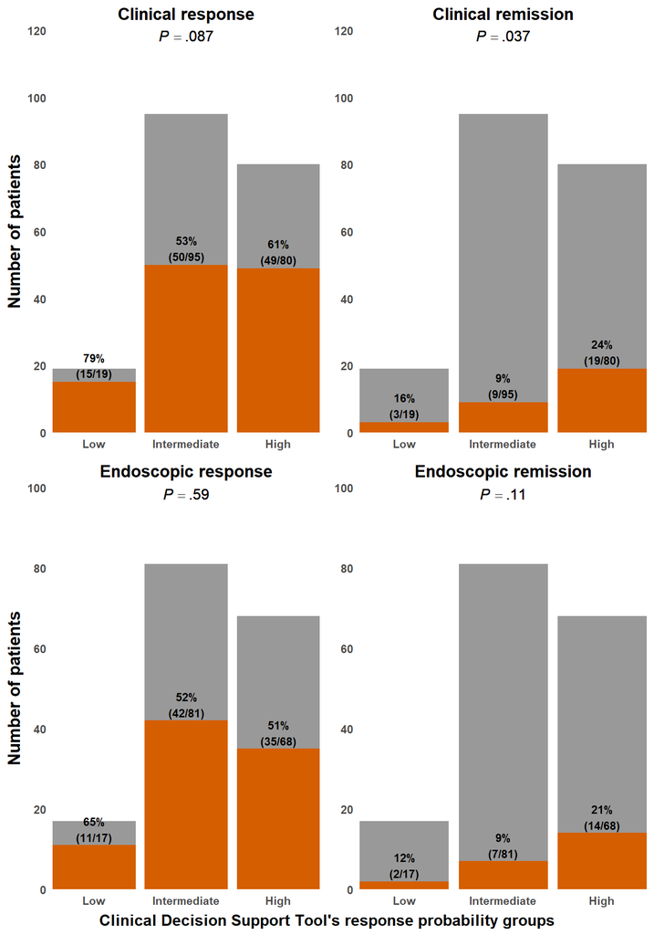

```r
ust_cd_bars_combined <- ggarrange(ust_cd_clinical_response_gg, ust_cd_clinical_remission_gg, ust_cd_endoscopic_response_gg, ust_cd_endoscopic_remission_gg, nrow = 2, ncol = 2)

annotate_figure(ust_cd_bars_combined, bottom = text_grob("Clinical Decision Support Tool's response probability groups", face = "bold", vjust = 0.1))
```

## 7. Calculate other discrimination metrics for effectiveness outcomes

### VDZ-CD

```r
vdz_cd_included %<>% mutate(cdst_category_high = cdst_category == "High")

vector_vdz_cd_discrimination <- vdz_cd_included %>%
  count(cdst_category_high, clinical_remission_cdst) %>%
  arrange(cdst_category_high, clinical_remission_cdst)

vector_vdz_cd_discrimination <- rev(vector_vdz_cd_discrimination$n)

epi_test_vdz_cd <- epi.tests(vector_vdz_cd_discrimination, method = "exact", digits = 2,
                             conf.level = 0.95)

roc_vdz_cd <- roc(vdz_cd_included$clinical_remission_cdst, vdz_cd_included$cdst_points)
```

### VDZ-UC

```r
vdz_uc_included %<>% mutate(cdst_category_high = cdst_category == "High")

vector_vdz_uc_discrimination <- vdz_uc_included %>%
  count(cdst_category_high, clinical_remission_cdst) %>%
  arrange(cdst_category_high, clinical_remission_cdst)

vector_vdz_uc_discrimination <- rev(vector_vdz_uc_discrimination$n)

epi_test_vdz_uc <- epi.tests(vector_vdz_uc_discrimination, method = "exact", digits = 2,
                             conf.level = 0.95)

roc_vdz_uc <- roc(vdz_uc_included$clinical_remission_cdst, vdz_uc_included$cdst_points)
```

### UST-CD

```r
ust_cd_included %<>% mutate(cdst_category_high = cdst_category == "High")

vector_ust_cd_discrimination <- ust_cd_included %>%
  count(cdst_category_high, clinical_remission_cdst) %>%
  arrange(cdst_category_high, clinical_remission_cdst)

vector_ust_cd_discrimination <- rev(vector_ust_cd_discrimination$n)

epi_test_ust_cd <- epi.tests(vector_ust_cd_discrimination, method = "exact", digits = 2,
                             conf.level = 0.95)
```

Combine metrics

```r
metrics_combined <- bind_rows("vdz-cd" = epi_test_vdz_cd$detail[epi_test_vdz_cd$detail[["statistic"]] %in% c("se", "sp", "lr.pos", "lr.neg"),],
                              "vdz-uc" = epi_test_vdz_uc$detail[epi_test_vdz_uc$detail[["statistic"]] %in% c("se", "sp", "lr.pos", "lr.neg"),],
                              "ust-cd" = epi_test_vdz_cd$detail[epi_test_vdz_cd$detail[["statistic"]] %in% c("se", "sp", "lr.pos", "lr.neg"),],
                              .id = "tool")

metrics_combined %<>%
  mutate(across(c(est, lower, upper), ~ if_else(statistic %in% c("se", "sp"), . * 100, .))) %>%
  mutate(across(c(est, lower, upper),
                ~ if_else(statistic %in% c("se", "sp"), round(., 1), round(., 2))))

metrics_combined %<>%
  mutate(across(where(is.numeric), ~ round(., 2))) %>%
  mutate(value = str_glue("{est} ({lower}-{upper})")) %>%
  select(-c(est, lower, upper))

metrics_combined %<>%
  pivot_wider(names_from = statistic, values_from = value)


roc_vdz_cd_ci <- glue("{round(ci(roc_vdz_cd)[2] * 100, 1)} ({round(ci(roc_vdz_cd)[1] * 100, 1)}-{round(ci(roc_vdz_cd)[3] * 100, 1)})")
roc_vdz_uc_ci <- glue("{round(ci(roc_vdz_uc)[2] * 100, 1)} ({round(ci(roc_vdz_uc)[1] * 100, 1)}-{round(ci(roc_vdz_uc)[3] * 100, 1)})")

metrics_combined <- cbind(metrics_combined, auc = c(roc_vdz_cd_ci, roc_vdz_uc_ci, "*"))

metrics_combined$tool <- c("VDZ in CD patients", "VDZ in UC patients", "UST in CD patients")

colnames(metrics_combined) <- c(
  "CDST",
  "Sensitivity (%) (95% CI)",
  "Specificity (%) (95% CI)",
  "PLR (95% CI)",
  "NLR (95% CI)",
  "AUC (%) (95% CI)"
)

metrics_combined %>%
  gt::gt() %>%
  gt::tab_style(
    style = gt::cell_text(align = "left"),
    locations = gt::cells_body(columns = c(CDST))
  ) %>%
  gt::tab_style(
    style = gt::cell_text(align = "center"),
    locations = gt::cells_body(columns = c(`Sensitivity (%) (95% CI)`, `Specificity (%) (95% CI)`, `PLR (95% CI)`, `NLR (95% CI)`, `AUC (%) (95% CI)`))
  ) %>%
  gt::tab_style(
    style = gt::cell_text(weight = "bold"),
    locations = gt::cells_column_labels(everything())
  )
```

[output not shown]

## 8. Get rates of therapy outcomes

```r
outcomes_not_endoscopic <- c("clinical_response", "clinical_response_pga", "clinical_response_cdst", "clinical_remission",
                             "clinical_remission_pga", "clinical_remission_cdst", "persistence", "persistence_without_escalation")

outcomes_endoscopic <- c("endoscopic_response", "endoscopic_response_cdst", "endoscopic_remission", "endoscopic_remission_cdst")



vdz_cd_outcomes_not_endoscopic <- outcome_pct(vdz_cd_included, outcomes_not_endoscopic)

vdz_cd_outcomes_endoscopic <- outcome_pct(vdz_cd_included_endoscopic, outcomes_endoscopic)

vdz_cd_outcomes <- bind_rows(vdz_cd_outcomes_endoscopic, vdz_cd_outcomes_not_endoscopic)



vdz_uc_outcomes_not_endoscopic <- outcome_pct(vdz_uc_included, outcomes_not_endoscopic)

vdz_uc_outcomes_endoscopic <- outcome_pct(vdz_uc_included_endoscopic, outcomes_endoscopic)

vdz_uc_outcomes <- bind_rows(vdz_uc_outcomes_endoscopic, vdz_uc_outcomes_not_endoscopic)



ust_cd_outcomes_not_endoscopic <- outcome_pct(ust_cd_included, outcomes_not_endoscopic)

ust_cd_outcomes_endoscopic <- outcome_pct(ust_cd_included_endoscopic, outcomes_endoscopic)

ust_cd_outcomes <- bind_rows(ust_cd_outcomes_endoscopic, ust_cd_outcomes_not_endoscopic)


combined_outcomes <- vdz_cd_outcomes %>% select(outcome, vdz_cd = report) %>%
  bind_cols(vdz_uc_outcomes %>% select(vdz_uc = report),
            ust_cd_outcomes %>% select(ust_cd = report)) %>%
  mutate(outcome = str_replace_all(outcome, "_", " "),
         outcome = str_to_sentence(outcome),
         outcome = str_replace(outcome, "cdst", "without escalation"))




combined_outcomes %>%
  gt::gt() %>%
  gt::cols_label(
    outcome = "Outcome",
    vdz_cd = "VDZ-CD",
    vdz_uc = "VDZ-UC",
    ust_cd = "UST-CD"
  ) %>%
  gt::tab_style(
    style = gt::cell_text(align = "left"),
    locations = gt::cells_body(columns = outcome)
  ) %>%
  gt::tab_style(
    style = gt::cell_text(align = "center"),
    locations = gt::cells_body(columns = c(vdz_cd, vdz_uc, ust_cd))
  ) %>%
  gt::tab_style(
    style = gt::cell_text(weight = "bold"),
    locations = gt::cells_column_labels(everything())
  )
```

| Outcome | VDZ-CD | VDZ-UC | UST-CD |
| --- | --- | --- | --- |
| Endoscopic response | 123/213 (57.7%) | 118/217 (54.4%) | 89/166 (53.6%) |
| Endoscopic response without escalation | 121/213 (56.8%) | 118/217 (54.4%) | 88/166 (53%) |
| Endoscopic remission | 64/213 (30%) | 74/217 (34.1%) | 24/166 (14.5%) |
| Endoscopic remission without escalation | 63/213 (29.6%) | 74/217 (34.1%) | 23/166 (13.9%) |
| Clinical response | 185/280 (66.1%) | 142/218 (65.1%) | 116/194 (59.8%) |
| Clinical response without escalation | 178/280 (63.6%) | 142/218 (65.1%) | 114/194 (58.8%) |
| Clinical remission | 45/280 (16.1%) | 51/218 (23.4%) | 31/194 (16%) |
| Clinical remission without escalation | 45/280 (16.1%) | 51/218 (23.4%) | 31/194 (16%) |

## 9. Calculate & visualize discrimination for trough levels

Load trough data and get it in shape for analysis

```r
load("input/VDZ_UST_troughs.RData")

UST_troughs_induction <- UST_troughs %>% filter(interval == 16)
VDZ_troughs_induction <- VDZ_troughs %>% filter(between(interval, 13, 15))

cdst_vdz_uc_troughs <- power_inner_join(vdz_uc_included %>% select_keys_and(cdst_category),
                                        VDZ_troughs_induction %>% select_keys_and(trough),
                                        by = "patient_id")
cdst_vdz_uc_troughs %>% count(cdst_category)
```

| cdst_category | n |
| --- | --- |
| Low | 6 |
| Intermediate | 54 |
| High | 45 |

```r
cdst_vdz_uc_troughs %<>% group_by(cdst_category) %>% mutate(median = round(median(trough),1), total = n()) %>% ungroup()


cdst_vdz_cd_troughs <- power_inner_join(vdz_cd_included %>% select_keys_and(cdst_category),
                                        VDZ_troughs_induction %>% select_keys_and(trough),
                                        by = "patient_id")
cdst_vdz_cd_troughs %>% count(cdst_category)
```

| cdst_category | n |
| --- | --- |
| Low | 11 |
| Intermediate | 80 |
| High | 55 |

```r
cdst_vdz_cd_troughs %<>% group_by(cdst_category) %>% mutate(median = round(median(trough),1), total = n()) %>% ungroup()


cdst_ust_cd_troughs <- power_inner_join(ust_cd_included %>% select_keys_and(cdst_category),
                                        VDZ_troughs_induction %>% select_keys_and(trough),
                                        by = "patient_id")
cdst_ust_cd_troughs %>% count(cdst_category)
```

| cdst_category | n |
| --- | --- |
| Low | 5 |
| Intermediate | 24 |
| High | 18 |

```r
cdst_ust_cd_troughs %<>% group_by(cdst_category) %>% mutate(median = round(median(trough),1), total = n()) %>% ungroup()

vdz_cd_troughs_medians <- cdst_vdz_cd_troughs %>%
  distinct(cdst_category, median, total)

vdz_uc_troughs_medians <- cdst_vdz_uc_troughs %>%
  distinct(cdst_category, median, total)

ust_cd_troughs_medians <- cdst_ust_cd_troughs %>%
  distinct(cdst_category, median, total)
```

Test for significance

```r
kruskal_vdz_cd_troughs <- kruskal.test(trough ~ cdst_category, data = cdst_vdz_cd_troughs)
kruskal_vdz_uc_troughs <- kruskal.test(trough ~ cdst_category, data = cdst_vdz_uc_troughs)
kruskal_ust_cd_troughs <- kruskal.test(trough ~ cdst_category, data = cdst_ust_cd_troughs)
```

Make box plots per cdst category

```r
vdz_cd_troughs_gg <- ggplot(data = cdst_vdz_cd_troughs, aes(x = cdst_category, y = trough)) +
  geom_boxplot(width = 0.35, outlier.shape = NA, coef = FALSE)+
  geom_jitter(size = 0.4) +
  geom_text(data = vdz_cd_troughs_medians, aes(label = str_c("median = ", median, " \n(n", "=", total, ")"), y = -0.5), size = 3, fontface = "bold") +
  coord_cartesian(expand = 1.5, ylim = c(0, 70)) +
  scale_y_continuous(breaks = seq(0, 70, 10)) +
  theme(axis.ticks.x = element_blank(),
        panel.background = element_blank(),
        axis.line.y = element_line(),
        axis.title = element_blank(),
        axis.text = element_text(face = "bold"),
        legend.position = "None") +
  annotate(geom = "text", label = format_p_value(kruskal_vdz_cd_troughs$p.value), x = 2, y = 68, size = 4, fontface = "bold")

vdz_uc_troughs_gg <- ggplot(data = cdst_vdz_uc_troughs, aes(x = cdst_category, y = trough)) +
  geom_boxplot(width = 0.35, outlier.shape = NA, coef = FALSE)+
  geom_jitter(size = 0.4) +
  geom_text(data = vdz_uc_troughs_medians, aes(label = str_c("median = ", median, " \n(n", "=", total, ")"), y = -0.5), size = 3, fontface = "bold") +
  coord_cartesian(expand = 1.5, ylim = c(0, 41)) +
  scale_y_continuous(breaks = seq(0, 41, 10)) +
  theme(axis.ticks.x = element_blank(),
        panel.background = element_blank(),
        axis.line.y = element_line(),
        axis.title = element_blank(),
        axis.text = element_text(face = "bold"),
        legend.position = "None") +
  annotate(geom = "text", label = format_p_value(kruskal_vdz_uc_troughs$p.value), x = 2, y = 40, size = 4, fontface = "bold")

ust_cd_troughs_gg <- ggplot(data = cdst_ust_cd_troughs, aes(x = cdst_category, y = trough)) +
  geom_boxplot(width = 0.35, outlier.shape = NA, coef = FALSE)+
  geom_jitter(size = 0.4) +
  geom_text(data = ust_cd_troughs_medians, aes(label = str_c("median = ", median, " \n(n", "=", total, ")"), y = -0.5), size = 3, fontface = "bold") +
  coord_cartesian(expand = 1.5, ylim = c(0, 50)) +
  scale_y_continuous(breaks = seq(0, 50, 10)) +
  theme(axis.ticks.x = element_blank(),
        panel.background = element_blank(),
        axis.line.y = element_line(),
        axis.title = element_blank(),
        axis.text = element_text(face = "bold"),
        legend.position = "None") +
  annotate(geom = "text", label = format_p_value(kruskal_ust_cd_troughs$p.value), x = 2, y = 48.8, size = 4, fontface = "bold")
```

Combine the plots

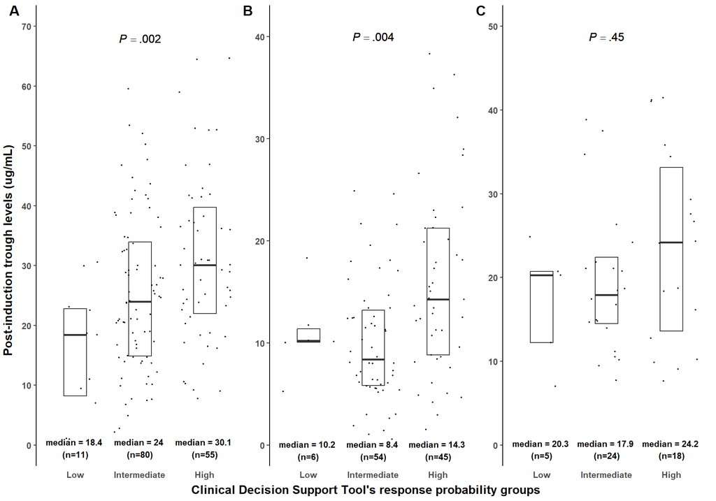

```r
troughs_combined <- ggarrange(vdz_cd_troughs_gg, vdz_uc_troughs_gg, ust_cd_troughs_gg, labels = c("A", "B", "C"), nrow = 1, ncol = 3,
                              label.x = c(-0.05, -0.05, -0.05))


annotate_figure(troughs_combined, bottom = text_grob("Clinical Decision Support Tool's response probability groups", face = "bold", vjust = 0.1),
                left = text_grob("Post-induction trough levels (ug/mL)", face = "bold", vjust = 0.4, rot = 90))
```

## 10. Calculate & visualize discrimination for dose optimization

### VDZ-CD

```r
vdz_cd_included %<>% mutate(dose_optimisation = recode(dose_optimisation,
                                                       "0" = FALSE,
                                                       "1" = TRUE))

vdz_cd_included %>% count(cdst_category, dose_optimisation)
```

| cdst_category | dose_optimisation | n |
| --- | --- | --- |
| Low | FALSE | 7 |
| Low | TRUE | 6 |
| Intermediate | FALSE | 88 |
| Intermediate | TRUE | 58 |
| High | FALSE | 82 |
| High | TRUE | 39 |

```r
chisq_vdz_cd_optimisation <- chisq.test(vdz_cd_included$cdst_category, vdz_cd_included$dose_optimisation)

vdz_cd_cdst_tabulation_optimisation <- vdz_cd_included %>%
  group_by(cdst_category) %>%
  summarise(total = n(),
            optimized = sum(dose_optimisation),
            percentage =scales::percent(optimized/total))

vdz_cd_optimisation_gg <- ggplot(data = vdz_cd_included, aes(x = cdst_category, fill = dose_optimisation)) +
  geom_bar() +
  scale_y_continuous(limits = c(0, 160), breaks = seq(0, 160, 20)) +
  scale_fill_manual(values = c("#D55E00", "#999999"), labels = c("yes", "no"), breaks = c(TRUE, FALSE)) +
  coord_cartesian(expand = 0) +
  labs(y = "Number of patients", title = "Crohn’s disease") +
  theme(axis.ticks = element_blank(),
        panel.background = element_blank(),
        axis.title = element_text(face = "bold"),
        axis.title.x = element_blank(),
        axis.text = element_text(face = "bold"),
        legend.position = "none",
        plot.title = element_text(hjust = 0.5, face = "bold", size = 13)) +
  annotate(geom = "text", label = paste0(vdz_cd_cdst_tabulation_optimisation$percentage, "\n", "(", vdz_cd_cdst_tabulation_optimisation$optimized, "/", vdz_cd_cdst_tabulation_optimisation$total, ")"),
           x = 1:3, y = vdz_cd_cdst_tabulation_optimisation$optimized + 4.5,
           size = 3, fontface = "bold") +
  annotate(geom = "text", label = format_p_value(chisq_vdz_cd_optimisation$p.value), x = 2, y = 158, size = 4, fontface = "bold")
```

### VDZ-UC

```r
vdz_uc_included %<>% mutate(dose_optimisation = recode(dose_optimisation,
                                                       "0" = FALSE,
                                                       "1" = TRUE))

vdz_uc_included %>% count(cdst_category, dose_optimisation)
```

| cdst_category | dose_optimisation | n |
| --- | --- | --- |
| Low | FALSE | 9 |
| Low | TRUE | 9 |
| Intermediate | FALSE | 62 |
| Intermediate | TRUE | 43 |
| High | FALSE | 66 |
| High | TRUE | 29 |

```r
chisq_vdz_uc_optimisation <- chisq.test(vdz_uc_included$cdst_category, vdz_uc_included$dose_optimisation)

vdz_uc_cdst_tabulation_optimisation <- vdz_uc_included %>%
  group_by(cdst_category) %>%
  summarise(total = n(),
            optimized = sum(dose_optimisation),
            percentage =scales::percent(optimized/total))

vdz_uc_optimisation_gg <- ggplot(data = vdz_uc_included, aes(x = cdst_category, fill = dose_optimisation)) +
  geom_bar() +
  scale_y_continuous(limits = c(0, 120), breaks = seq(0, 120, 20)) +
  scale_fill_manual(values = c("#D55E00", "#999999"), labels = c("yes", "no"), breaks = c(TRUE, FALSE)) +
  coord_cartesian(expand = 0) +
  labs(title = "Ulcerative Colitis") +
  theme(axis.ticks = element_blank(),
        panel.background = element_blank(),
        axis.title = element_text(face = "bold"),
        axis.title.x = element_blank(),
        axis.title.y = element_blank(),
        axis.text = element_text(face = "bold"),
        legend.position = "none",
        plot.title = element_text(hjust = 0.5, face = "bold", size = 13)) +
  annotate(geom = "text", label = paste0(vdz_uc_cdst_tabulation_optimisation$percentage, "\n", "(", vdz_uc_cdst_tabulation_optimisation$optimized, "/", vdz_uc_cdst_tabulation_optimisation$total, ")"),
           x = 1:3, y = vdz_uc_cdst_tabulation_optimisation$optimized + 3.3,
           size = 3, fontface = "bold") +
  annotate(geom = "text", label = format_p_value(chisq_vdz_uc_optimisation$p.value), x = 2, y = 118.4, size = 4, fontface = "bold")
```

Combine plots in 2 panels

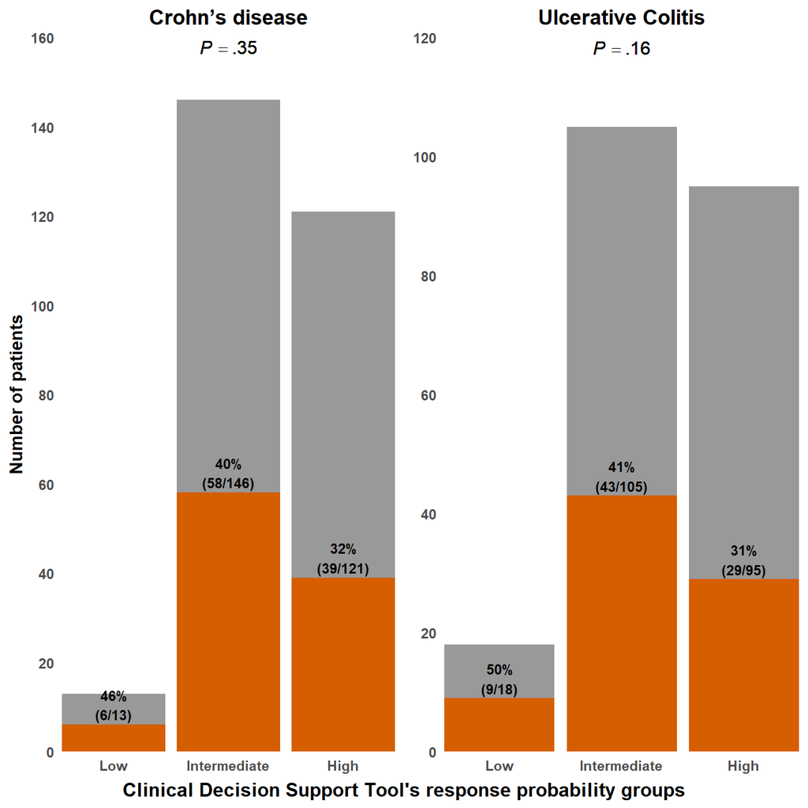

```r
vdz_uc_optimisation_combined <- ggarrange(vdz_cd_optimisation_gg, vdz_uc_optimisation_gg, nrow = 1, ncol = 2)


annotate_figure(vdz_uc_optimisation_combined, bottom = text_grob("Clinical Decision Support Tool's response probability groups", face = "bold", vjust = 0.1))
```

## 11. Assess specificity of the VDZ-CD tool in UST-CD cohort

Prepare VDZ-CD tool variables

```r
ust_cd_included %<>% mutate(no_previous_antitnf = if_else(previous_antitnf == 1, 0, 1), .after = previous_antitnf)

is.numeric(ust_cd_included$no_previous_antitnf)
```

```
[1] TRUE
```

```r
ust_cd_included %<>% mutate(no_surgery_before = if_else(intestinal_resections_before == 1, 0, 1), .after = intestinal_resections_before)

is.numeric(ust_cd_included$no_surgery_before)
```

```
[1] TRUE
```

```r
ust_cd_included %<>% mutate(no_fistulizing_before = if_else(fistulizing_disease_prior == 1, 0, 1), .after = fistulizing_disease_prior)

is.numeric(ust_cd_included$no_fistulizing_before)
```

```
[1] TRUE
```

```r
is.numeric(ust_cd_included$albumin_g_L)
```

```
[1] TRUE
```

```r
is.numeric(ust_cd_included$crp_mg_L)
```

```
[1] TRUE
```

Calculate CDST points for the vdz tool

```r
ust_cd_included %<>% mutate(cdst_points_vdz = 2*no_surgery_before + 3*no_previous_antitnf + 2*no_fistulizing_before + 0.4*albumin_g_L - case_when(crp_mg_L >= 3 & crp_mg_L <= 10 ~ 0.5,
                                                                                                                                                  crp_mg_L > 10 ~ 3,
                                                                                                                                                  .default = 0))
```

Assign CDST categories for the vdz tool

```r
ust_cd_included %<>% mutate(cdst_category_vdz = case_when(cdst_points_vdz <= 13 ~ "Low",
                                                          cdst_points_vdz > 13 & cdst_points_vdz <= 19 ~ "Intermediate",
                                                          cdst_points_vdz > 19 ~ "High")
)

ust_cd_included %>% count(cdst_category_vdz)
```

| cdst_category_vdz | n |
| --- | --- |
| High | 67 |
| Intermediate | 114 |
| Low | 13 |

```r
ust_cd_included$cdst_category_vdz <- factor(ust_cd_included$cdst_category_vdz, levels = c("Low", "Intermediate", "High"), ordered = TRUE)
```

Get agreement percentage between vdz and ust tools

```r
ust_cd_included %>%
  summarise(agreement = round(sum(cdst_category == cdst_category_vdz)/n()*100, 1))
```

| agreement |
| --- |
| 73.7 |

```r
ust_cd_included %>%
  filter(clinical_remission_cdst == 1) %>%
  summarise(agreement = round(sum(cdst_category == cdst_category_vdz)/n()*100, 1))
```

| agreement |
| --- |
| 77.4 |

```r
ust_cd_included %>%
  filter(clinical_response_cdst == 0) %>%
  summarise(agreement = round(sum(cdst_category == cdst_category_vdz)/n()*100, 1))
```

| agreement |
| --- |
| 73.8 |

Calculate discrimination percentages for: Clinica response

```r
chisq_ust_cd_clinical_response_vdz <- chisq.test(ust_cd_included$cdst_category_vdz, ust_cd_included$clinical_response_cdst)

ust_cd_cdst_tabulation_clinical_response_vdz <- ust_cd_included %>%
  group_by(cdst_category_vdz) %>%
  summarise(total = n(),
            achieved = sum(clinical_response_cdst),
            percentage =scales::percent(achieved/total))
```

Clinica remission

```r
chisq_ust_cd_clinical_remission_vdz <- chisq.test(ust_cd_included$cdst_category_vdz, ust_cd_included$clinical_remission_cdst)

ust_cd_cdst_tabulation_clinical_remission_vdz <- ust_cd_included %>%
  group_by(cdst_category_vdz) %>%
  summarise(total = n(),
            achieved = sum(clinical_remission_cdst),
            percentage =scales::percent(achieved/total))
```

Endoscopic response

```r
ust_cd_included_endoscopic <- power_left_join(ust_cd_included_endoscopic,
                                              ust_cd_included %>% select_keys_and(cdst_category_vdz),
                                              by = "patient_id")

chisq_ust_cd_endoscopic_response_vdz <- chisq.test(ust_cd_included_endoscopic$cdst_category_vdz, ust_cd_included_endoscopic$endoscopic_response_cdst)

ust_cd_cdst_tabulation_endoscopic_response_vdz <- ust_cd_included_endoscopic %>%
  group_by(cdst_category_vdz) %>%
  summarise(total = n(),
            achieved = sum(endoscopic_response_cdst),
            percentage =scales::percent(achieved/total))
```

Endoscopic remission

```r
chisq_ust_cd_endoscopic_remission_vdz <- chisq.test(ust_cd_included_endoscopic$cdst_category_vdz, ust_cd_included_endoscopic$endoscopic_remission_cdst)

ust_cd_cdst_tabulation_endoscopic_remission_vdz <- ust_cd_included_endoscopic %>%
  group_by(cdst_category_vdz) %>%
  summarise(total = n(),
            achieved = sum(endoscopic_remission_cdst),
            percentage =scales::percent(achieved/total))
```

Visualize discrimination bars

```r
ust_cd_clinical_response_vdz_gg <- ggplot(data = ust_cd_included, aes(x = cdst_category_vdz, fill = clinical_response_cdst)) +
  geom_bar() +
  scale_y_continuous(limits = c(0, 140), breaks = seq(0, 140, 20)) +
  scale_fill_manual(values = c("#D55E00", "#999999"), labels = c("yes", "no"), breaks = c(TRUE, FALSE)) +
  coord_cartesian(expand = 0) +
  labs(y = "Number of patients", title = "Clinical response") +
  theme(axis.ticks = element_blank(),
        panel.background = element_blank(),
        axis.title = element_text(face = "bold", size = 13),
        plot.title = element_text(hjust = 0.5, face = "bold", size = 13),
        axis.title.x = element_blank(),
        axis.text = element_text(face = "bold"),
        legend.position = "none") +
  annotate(geom = "text", label = paste0(ust_cd_cdst_tabulation_clinical_response_vdz$percentage, "\n", "(", ust_cd_cdst_tabulation_clinical_response_vdz$achieved, "/", ust_cd_cdst_tabulation_clinical_response_vdz$total, ")"),
           x = 1:3, y = ust_cd_cdst_tabulation_clinical_response_vdz$achieved + 6,
           size = 3, fontface = "bold") +
  annotate(geom = "text", label = format_p_value(chisq_ust_cd_clinical_response_vdz$p.value), x = 2, y = 138.5, size = 4, fontface = "bold")

ust_cd_clinical_remission_vdz_gg <- ggplot(data = ust_cd_included, aes(x = cdst_category_vdz, fill = clinical_remission_cdst)) +
  geom_bar() +
  scale_y_continuous(limits = c(0, 140), breaks = seq(0, 140, 20)) +
  scale_fill_manual(values = c("#D55E00", "#999999"), labels = c("yes", "no"), breaks = c(TRUE, FALSE)) +
  coord_cartesian(expand = 0) +
  labs(title = "Clinical remission") +
  theme(axis.ticks = element_blank(),
        panel.background = element_blank(),
        axis.title = element_text(face = "bold", size = 13),
        plot.title = element_text(hjust = 0.5, face = "bold", size = 13),
        axis.title.x = element_blank(),
        axis.title.y = element_blank(),
        axis.text = element_text(face = "bold"),
        legend.position = "none") +
  annotate(geom = "text", label = paste0(ust_cd_cdst_tabulation_clinical_remission_vdz$percentage, "\n", "(", ust_cd_cdst_tabulation_clinical_remission_vdz$achieved, "/", ust_cd_cdst_tabulation_clinical_remission_vdz$total, ")"),
           x = 1:3, y = ust_cd_cdst_tabulation_clinical_remission_vdz$achieved + 6,
           size = 3, fontface = "bold") +
  annotate(geom = "text", label = format_p_value(chisq_ust_cd_clinical_remission_vdz$p.value), x = 2, y = 138.5, size = 4, fontface = "bold")

ust_cd_endoscopic_response_vdz_gg <- ggplot(data = ust_cd_included_endoscopic, aes(x = cdst_category_vdz, fill = endoscopic_response_cdst)) +
  geom_bar() +
  scale_y_continuous(limits = c(0, 120), breaks = seq(0, 120, 20)) +
  scale_fill_manual(values = c("#D55E00", "#999999"), labels = c("yes", "no"), breaks = c(TRUE, FALSE)) +
  coord_cartesian(expand = 0) +
  labs(y = "Number of patients", title = "Endoscopic response") +
  theme(axis.ticks = element_blank(),
        panel.background = element_blank(),
        axis.title = element_text(face = "bold", size = 13),
        plot.title = element_text(hjust = 0.5, face = "bold", size = 13),
        axis.title.x = element_blank(),
        axis.text = element_text(face = "bold"),
        legend.position = "none") +
  annotate(geom = "text", label = paste0(ust_cd_cdst_tabulation_endoscopic_response_vdz$percentage, "\n", "(", ust_cd_cdst_tabulation_endoscopic_response_vdz$achieved, "/", ust_cd_cdst_tabulation_endoscopic_response_vdz$total, ")"),
           x = 1:3, y = ust_cd_cdst_tabulation_endoscopic_response_vdz$achieved + 5.3,
           size = 3, fontface = "bold") +
  annotate(geom = "text", label = format_p_value(chisq_ust_cd_endoscopic_response_vdz$p.value), x = 2, y = 118.5, size = 4, fontface = "bold")

ust_cd_endoscopic_remission_vdz_gg <- ggplot(data = ust_cd_included_endoscopic, aes(x = cdst_category_vdz, fill = endoscopic_remission_cdst)) +
  geom_bar() +
  scale_y_continuous(limits = c(0, 120), breaks = seq(0, 120, 20)) +
  scale_fill_manual(values = c("#D55E00", "#999999"), labels = c("yes", "no"), breaks = c(TRUE, FALSE)) +
  coord_cartesian(expand = 0) +
  labs(title = "Endoscopic remission") +
  theme(axis.ticks = element_blank(),
        panel.background = element_blank(),
        axis.title = element_text(face = "bold", size = 13),
        plot.title = element_text(hjust = 0.5, face = "bold", size = 13),
        axis.title.x = element_blank(),
        axis.title.y = element_blank(),
        axis.text = element_text(face = "bold"),
        legend.position = "none") +
  annotate(geom = "text", label = paste0(ust_cd_cdst_tabulation_endoscopic_remission_vdz$percentage, "\n", "(", ust_cd_cdst_tabulation_endoscopic_remission_vdz$achieved, "/", ust_cd_cdst_tabulation_endoscopic_remission_vdz$total, ")"),
           x = 1:3, y = ust_cd_cdst_tabulation_endoscopic_remission_vdz$achieved + 5.3,
           size = 3, fontface = "bold") +
  annotate(geom = "text", label = format_p_value(chisq_ust_cd_endoscopic_remission_vdz$p.value), x = 2, y = 118.5, size = 4, fontface = "bold")
```

Combine plots in 4 panels

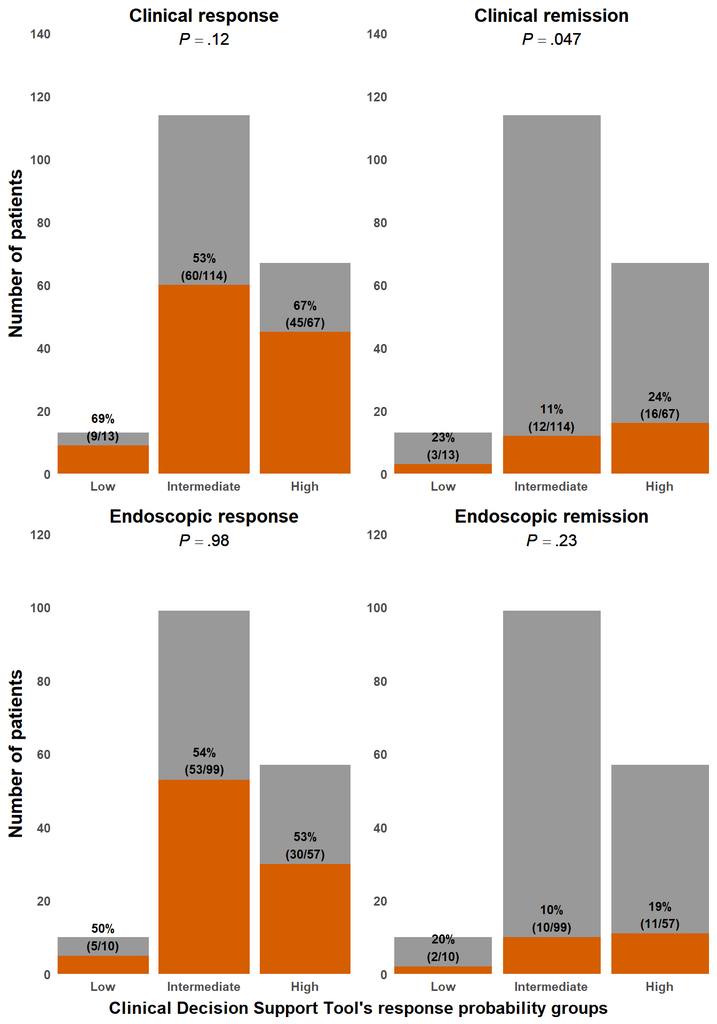

```r
ust_cd_vdz_bars_combined <- ggarrange(ust_cd_clinical_response_vdz_gg, ust_cd_clinical_remission_vdz_gg, ust_cd_endoscopic_response_vdz_gg, ust_cd_endoscopic_remission_vdz_gg, nrow = 2, ncol = 2)


annotate_figure(ust_cd_vdz_bars_combined, bottom = text_grob("Clinical Decision Support Tool's response probability groups", face = "bold", vjust = 0.1))
```

## 12. Evaluate CDST calibration

Calculate logits and convert them to probabilities

```r
vdz_cd_included %<>%
  mutate(logit = -3.0722 +  0.2305*no_surgery_before + 0.3483*no_previous_antitnf + 0.1979*no_fistulizing_before + 0.0436*albumin_g_L - 0.0098*crp_mg_L,
         prob = logit2prob(logit))

vdz_uc_included %<>%
  mutate(logit = -3.7038 + 0.2622*dxduration_above_two + 0.2820*no_previous_antitnf + 0.1847*moderate_endo_activity + 0.0647*albumin_g_L,
         prob = logit2prob(logit))
```

Define a clinically-relevant outcome: persistence & persistence without escalation

```r
vdz_cd_included %<>% mutate(persistence_without_escalation = stop_current_drug_itt == 0 & dose_optimisation == 0)
vdz_uc_included %<>% mutate(persistence_without_escalation = stop_current_drug_itt == 0 & dose_optimisation == 0)
ust_cd_included %<>% mutate(persistence_without_escalation = stop_current_drug_itt == 0 & dose_optimisation == 0)

vdz_cd_included %<>% mutate(persistence = stop_current_drug_itt == 0)
vdz_uc_included %<>% mutate(persistence = stop_current_drug_itt == 0)
ust_cd_included %<>% mutate(persistence = stop_current_drug_itt == 0)
```

Visualize calibration plots

```r
par(mfrow=c(3,2))

rms::val.prob(vdz_cd_included$prob, vdz_cd_included$clinical_remission_cdst, statloc = F, logistic.cal = F, g = 10)
```

```
            Dxy         C (ROC)              R2               D        D:Chi-sq
  0.17862884161   0.58931442080  -0.08314444580  -0.05113826943 -13.31871543951
            D:p               U        U:Chi-sq             U:p               Q
             NA   0.05932023319  18.60966529419   0.00009098348  -0.11045850262
          Brier       Intercept           Slope            Emax             E90
  0.14476423642  -0.65070440020   1.01127074257   0.16792792579   0.16166755327
           Eavg             S:z             S:p
  0.10881941218  -3.82536680788   0.00013057752
```

```r
mtext('A', adj = 0, line = 1, font = 2)

rms::val.prob(vdz_uc_included$prob, vdz_uc_included$clinical_remission_cdst, statloc = F, logistic.cal = F, g = 10)
```

```
          Dxy       C (ROC)            R2             D      D:Chi-sq
 0.3035106258  0.6517553129 -0.0616547022 -0.0446573598 -8.7353044358
          D:p             U      U:Chi-sq           U:p             Q
           NA  0.0567842995 14.3789772935  0.0007544748 -0.1014416593
        Brier     Intercept         Slope          Emax           E90
 0.1867562420 -0.5028711530  1.1430083801  0.4119663381  0.1703225522
         Eavg           S:z           S:p
 0.1209726878 -3.4821176169  0.0004974651
```

```r
mtext('B', adj = 0, line = 1, font = 2)

rms::val.prob(vdz_cd_included$prob, vdz_cd_included$persistence_without_escalation, statloc = F, logistic.cal = F, g = 10)
```

```
         Dxy      C (ROC)           R2            D     D:Chi-sq          D:p
 0.357506793  0.678753397  0.068796680  0.047490031 14.297208726           NA
           U     U:Chi-sq          U:p            Q        Brier    Intercept
 0.042172491 13.808297370  0.001003613  0.005317541  0.215184305  1.270721589
       Slope         Emax          E90         Eavg          S:z          S:p
 1.928436064  0.319500179  0.189713594  0.090107399  2.020589697  0.043322256
```

```r
mtext('C', adj = 0, line = 1, font = 2)

rms::val.prob(vdz_uc_included$prob, vdz_uc_included$persistence_without_escalation, statloc = F, logistic.cal = F, g = 10)
```

```
        Dxy     C (ROC)          R2           D    D:Chi-sq         D:p
 0.31491549  0.65745774  0.07109483  0.04712249 11.27270173          NA
          U    U:Chi-sq         U:p           Q       Brier   Intercept
 0.01502521  5.27549670  0.07152213  0.03209727  0.20177544  0.30622051
      Slope        Emax         E90        Eavg         S:z         S:p
 1.89496508  0.18284498  0.10107597  0.06405022 -1.99595232  0.04593911
```

```r
mtext('D', adj = 0, line = 1, font = 2)

rms::val.prob(vdz_cd_included$prob, vdz_cd_included$persistence, statloc = F, logistic.cal = F, g = 10)
```

```
                       Dxy                    C (ROC)
  0.3067973055725658482196   0.6533986527862829518654
                        R2                          D
 -0.2791177371817529229148  -0.1936330041949115565725
                  D:Chi-sq                        D:p
-53.2172411745752356182493                         NA
                         U                   U:Chi-sq
  0.2710559208947198595041  77.8956578505215588847932
                       U:p                          Q
  0.0000000000000000000000  -0.4646889250896314438322
                     Brier                  Intercept
  0.2920824410165137607898   1.7383988222184387772984
                     Slope                       Emax
  1.6477130652951839095977   0.3993827373260716573355
                       E90                       Eavg
  0.3285369249726436402526   0.2405269877686071477996
                       S:z                        S:p
  8.4043262035508128349193   0.0000000000000000430325
```

```r
mtext('E', adj = 0, line = 1, font = 2)

rms::val.prob(vdz_uc_included$prob, vdz_uc_included$persistence, statloc = F, logistic.cal = F, g = 10)
```

```
        Dxy     C (ROC)          R2           D    D:Chi-sq         D:p
 0.26418485  0.63209243  0.02392832  0.01342047  3.92566262          NA
          U    U:Chi-sq         U:p           Q       Brier   Intercept
 0.02648111  7.77288151  0.02051825 -0.01306064  0.24170389  0.61371546
      Slope        Emax         E90        Eavg         S:z         S:p
 1.40477097  0.16086479  0.14688310  0.08653667  1.95501037  0.05058185
```

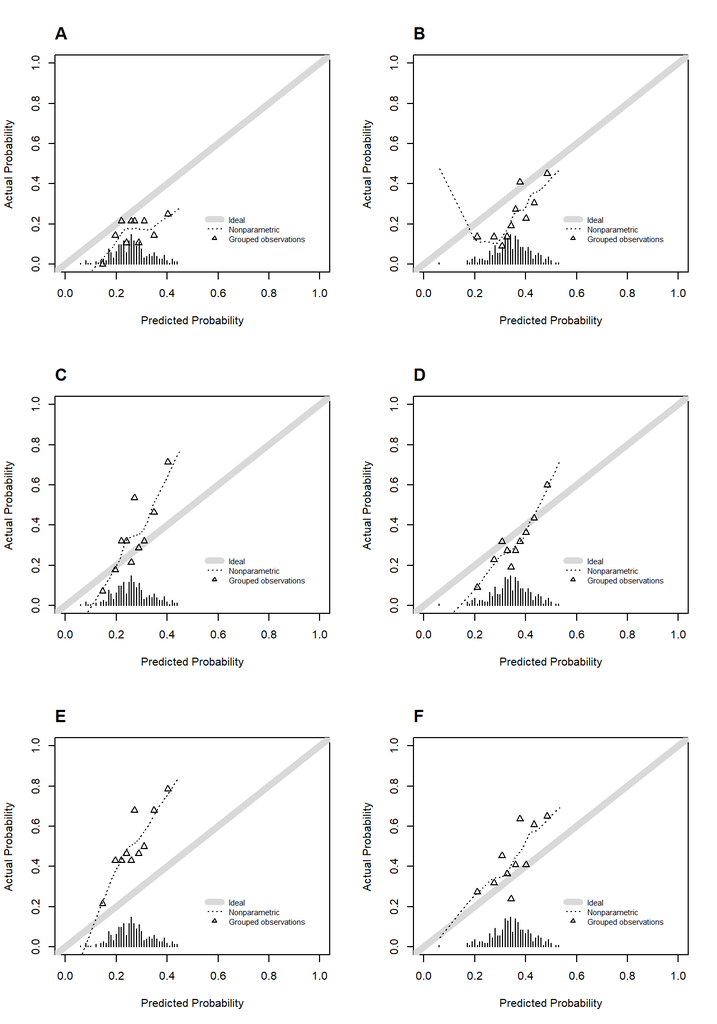

```r
mtext('F', adj = 0, line = 1, font = 2)
```

## 13. Decision curve analysis

### Plot the curves

For clinical remission

```r
vdz_cd_dca_plot_remission <- dca(clinical_remission_cdst ~ prob,
                       data = vdz_cd_included,
                       thresholds = seq(0, 0.5, 0.01),
                       label = list(prob = "Clinical Decision Support Tool")) %>%
  plot(smooth = FALSE, style = "bw") + theme(panel.grid = element_blank()) +
  scale_x_continuous(breaks = seq(0, 0.5, 0.05), labels = scales::percent_format(accuracy = 1)) +
  scale_y_continuous(breaks = seq(0, 0.7, 0.1))

vdz_uc_dca_plot_remission <- dca(clinical_remission_cdst ~ prob,
                       data = vdz_uc_included,
                       thresholds = seq(0, 0.55, 0.01),
                       label = list(prob = "Clinical Decision Support Tool")) %>%
  plot(smooth = FALSE, style = "bw") + theme(panel.grid = element_blank()) +
  scale_x_continuous(breaks = seq(0, 0.55, 0.05), labels = scales::percent_format(accuracy = 1)) +
  scale_y_continuous(breaks = seq(0, 0.6, 0.1))
```

For persistence without escalation

```r
vdz_cd_dca_plot_persistence_without_escalation <- dca(persistence_without_escalation ~ prob,
                                 data = vdz_cd_included,
                                 thresholds = seq(0, 0.5, 0.01),
                                 label = list(prob = "Clinical Decision Support Tool")) %>%
  plot(smooth = FALSE, style = "bw") + theme(panel.grid = element_blank()) +
  scale_x_continuous(breaks = seq(0, 0.5, 0.05), labels = scales::percent_format(accuracy = 1)) +
  scale_y_continuous(breaks = seq(0, 0.7, 0.1))

vdz_uc_dca_plot_persistence_without_escalation <- dca(persistence_without_escalation ~ prob,
                                 data = vdz_uc_included,
                                 thresholds = seq(0, 0.55, 0.01),
                                 label = list(prob = "Clinical Decision Support Tool")) %>%
  plot(smooth = FALSE, style = "bw") + theme(panel.grid = element_blank()) +
  scale_x_continuous(breaks = seq(0, 0.55, 0.05), labels = scales::percent_format(accuracy = 1)) +
  scale_y_continuous(breaks = seq(0, 0.6, 0.1))
```

For persistence

```r
vdz_cd_dca_plot_persistence <- dca(persistence ~ prob,
                                                      data = vdz_cd_included,
                                                      thresholds = seq(0, 0.5, 0.01),
                                                      label = list(prob = "Clinical Decision Support Tool")) %>%
  plot(smooth = FALSE, style = "bw") + theme(panel.grid = element_blank()) +
  scale_x_continuous(breaks = seq(0, 0.5, 0.05), labels = scales::percent_format(accuracy = 1)) +
  scale_y_continuous(breaks = seq(0, 0.7, 0.1))

vdz_uc_dca_plot_persistence <- dca(persistence ~ prob,
                                                      data = vdz_uc_included,
                                                      thresholds = seq(0, 0.55, 0.01),
                                                      label = list(prob = "Clinical Decision Support Tool")) %>%
  plot(smooth = FALSE, style = "bw") + theme(panel.grid = element_blank()) +
  scale_x_continuous(breaks = seq(0, 0.55, 0.05), labels = scales::percent_format(accuracy = 1)) +
  scale_y_continuous(breaks = seq(0, 0.6, 0.1))
```

Combine the plots

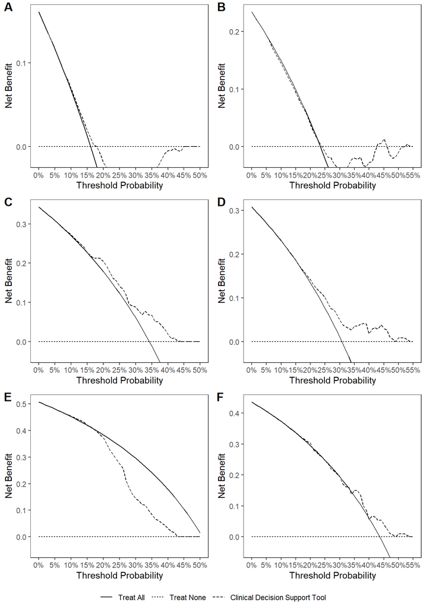

```r
ggarrange(vdz_cd_dca_plot_remission, vdz_uc_dca_plot_remission,
          vdz_cd_dca_plot_persistence_without_escalation, vdz_uc_dca_plot_persistence_without_escalation,
          vdz_cd_dca_plot_persistence, vdz_uc_dca_plot_persistence,
          labels = c("A", "B", "C", "D", "E", "F"), label.y = c(1.012, 1.012, 1.012, 1.012, 1.012, 1.012), nrow = 3, ncol = 2,
          common.legend = TRUE, legend="bottom")
```

### Make net benefit tables

For clinical remission

```r
vdz_cd_dca_tbl_remission <- dca(clinical_remission_cdst ~ prob,
                                data = vdz_cd_included,
                                thresholds = seq(0.1, 0.5, 0.1),
                                label = list(prob = "Clinical Decision Support Tool")) %>%
  as_tibble() %>%
  select(label, threshold, net_benefit)

vdz_uc_dca_tbl_remission <- dca(clinical_remission_cdst ~ prob,
                                data = vdz_uc_included,
                                thresholds = seq(0.1, 0.5, 0.1),
                                label = list(prob = "Clinical Decision Support Tool")) %>%
  as_tibble() %>%
  select(label, threshold, net_benefit)


combined_dca_tbl_remission <- bind_cols(
  vdz_cd_dca_tbl_remission %>%
    rename_with(~ paste0("cd_", .)),
  vdz_uc_dca_tbl_remission %>%
    rename_with(~ paste0("uc_", .))
)

combined_dca_tbl_remission %>%
  gt::gt() %>%
  gt::cols_label(
    cd_label = "Strategy",
    cd_threshold = "Decision Threshold",
    cd_net_benefit = "Net Benefit",
    uc_label = "Strategy",
    uc_threshold = "Decision Threshold",
    uc_net_benefit = "Net Benefit"
  ) %>%
  gt::fmt_percent(
    columns = c(cd_threshold, uc_threshold),
    decimals = 0
  ) %>%
  gt::fmt(
    columns = c(cd_net_benefit, uc_net_benefit),
    fns = function(x) ifelse(x == 0, "0", formatC(x, format = "f", digits = 3))
  ) %>%
  gt::tab_spanner(
    label = "Crohn's Disease",
    columns = c(cd_label, cd_threshold, cd_net_benefit)
  ) %>%
  gt::tab_spanner(
    label = "Ulcerative Colitis",
    columns = c(uc_label, uc_threshold, uc_net_benefit)
  ) %>%
  gt::cols_align("left", columns = everything()) %>%
  gt::tab_style(
    style = gt::cell_text(weight = "bold"),
    locations = gt::cells_column_spanners(spanners = c("Crohn's Disease", "Ulcerative Colitis"))
  ) %>%
  gt::tab_style(
    style = gt::cell_text(weight = "bold"),
    locations = gt::cells_column_labels(columns = everything())
  )
```

| Crohn's Disease Strategy | Crohn's Disease Decision Threshold | Crohn's Disease Net Benefit | Ulcerative Colitis Strategy | Ulcerative Colitis Decision Threshold | Ulcerative Colitis Net Benefit |
| --- | --- | --- | --- | --- | --- |
| Treat All | 10% | 0.067 | Treat All | 10% | 0.149 |
| Treat All | 20% | -0.049 | Treat All | 20% | 0.042 |
| Treat All | 30% | -0.199 | Treat All | 30% | -0.094 |
| Treat All | 40% | -0.399 | Treat All | 40% | -0.277 |
| Treat All | 50% | -0.679 | Treat All | 50% | -0.532 |
| Treat None | 10% | 0 | Treat None | 10% | 0 |
| Treat None | 20% | 0 | Treat None | 20% | 0 |
| Treat None | 30% | 0 | Treat None | 30% | 0 |
| Treat None | 40% | 0 | Treat None | 40% | 0 |
| Treat None | 50% | 0 | Treat None | 50% | 0 |
| Clinical Decision Support Tool | 10% | 0.069 | Clinical Decision Support Tool | 10% | 0.144 |
| Clinical Decision Support Tool | 20% | -0.019 | Clinical Decision Support Tool | 20% | 0.039 |
| Clinical Decision Support Tool | 30% | -0.034 | Clinical Decision Support Tool | 30% | -0.042 |
| Clinical Decision Support Tool | 40% | -0.005 | Clinical Decision Support Tool | 40% | -0.028 |
| Clinical Decision Support Tool | 50% | 0 | Clinical Decision Support Tool | 50% | -0.009 |

For persistence without escalation

```r
vdz_cd_dca_tbl_persistence_without_escalation <- dca(persistence_without_escalation ~ prob,
                                                     data = vdz_cd_included,
                                                     thresholds = seq(0.1, 0.5, 0.1),
                                                     label = list(prob = "Clinical Decision Support Tool")) %>%
  as_tibble() %>%
  select(label, threshold, net_benefit)

vdz_uc_dca_tbl_persistence_without_escalation <- dca(persistence_without_escalation ~ prob,
                                                     data = vdz_uc_included,
                                                     thresholds = seq(0.1, 0.5, 0.1),
                                                     label = list(prob = "Clinical Decision Support Tool")) %>%
  as_tibble() %>%
  select(label, threshold, net_benefit)


combined_dca_tbl_persistence_without_escalation <- bind_cols(
  vdz_cd_dca_tbl_persistence_without_escalation %>%
    rename_with(~ paste0("cd_", .)),
  vdz_uc_dca_tbl_persistence_without_escalation %>%
    rename_with(~ paste0("uc_", .))
)

combined_dca_tbl_persistence_without_escalation %>%
  gt::gt() %>%
  gt::cols_label(
    cd_label = "Strategy",
    cd_threshold = "Decision Threshold",
    cd_net_benefit = "Net Benefit",
    uc_label = "Strategy",
    uc_threshold = "Decision Threshold",
    uc_net_benefit = "Net Benefit"
  ) %>%
  gt::fmt_percent(
    columns = c(cd_threshold, uc_threshold),
    decimals = 0
  ) %>%
  gt::fmt(
    columns = c(cd_net_benefit, uc_net_benefit),
    fns = function(x) ifelse(x == 0, "0", formatC(x, format = "f", digits = 3))
  ) %>%
  gt::tab_spanner(
    label = "Crohn's Disease",
    columns = c(cd_label, cd_threshold, cd_net_benefit)
  ) %>%
  gt::tab_spanner(
    label = "Ulcerative Colitis",
    columns = c(uc_label, uc_threshold, uc_net_benefit)
  ) %>%
  gt::cols_align("left", columns = everything()) %>%
  gt::tab_style(
    style = gt::cell_text(weight = "bold"),
    locations = gt::cells_column_spanners(spanners = c("Crohn's Disease", "Ulcerative Colitis"))
  ) %>%
  gt::tab_style(
    style = gt::cell_text(weight = "bold"),
    locations = gt::cells_column_labels(columns = everything())
  )
```

| Crohn's Disease Strategy | Crohn's Disease Decision Threshold | Crohn's Disease Net Benefit | Ulcerative Colitis Strategy | Ulcerative Colitis Decision Threshold | Ulcerative Colitis Net Benefit |
| --- | --- | --- | --- | --- | --- |
| Treat All | 10% | 0.270 | Treat All | 10% | 0.230 |
| Treat All | 20% | 0.179 | Treat All | 20% | 0.134 |
| Treat All | 30% | 0.061 | Treat All | 30% | 0.010 |
| Treat All | 40% | -0.095 | Treat All | 40% | -0.154 |
| Treat All | 50% | -0.314 | Treat All | 50% | -0.385 |
| Treat None | 10% | 0 | Treat None | 10% | 0 |
| Treat None | 20% | 0 | Treat None | 20% | 0 |
| Treat None | 30% | 0 | Treat None | 30% | 0 |
| Treat None | 40% | 0 | Treat None | 40% | 0 |
| Treat None | 50% | 0 | Treat None | 50% | 0 |
| Clinical Decision Support Tool | 10% | 0.272 | Clinical Decision Support Tool | 10% | 0.231 |
| Clinical Decision Support Tool | 20% | 0.204 | Clinical Decision Support Tool | 20% | 0.142 |
| Clinical Decision Support Tool | 30% | 0.088 | Clinical Decision Support Tool | 30% | 0.050 |
| Clinical Decision Support Tool | 40% | 0.019 | Clinical Decision Support Tool | 40% | 0.018 |
| Clinical Decision Support Tool | 50% | 0 | Clinical Decision Support Tool | 50% | 0.009 |

For persistence

```r
vdz_cd_dca_tbl_persistence <- dca(persistence ~ prob,
                                  data = vdz_cd_included,
                                  thresholds = seq(0.1, 0.5, 0.1),
                                  label = list(prob = "Clinical Decision Support Tool")) %>%
  as_tibble() %>%
  select(label, threshold, net_benefit)

vdz_uc_dca_tbl_persistence <- dca(persistence ~ prob,
                                  data = vdz_uc_included,
                                  thresholds = seq(0.1, 0.5, 0.1),
                                  label = list(prob = "Clinical Decision Support Tool")) %>%
  as_tibble() %>%
  select(label, threshold, net_benefit)


combined_dca_tbl_persistence <- bind_cols(
  vdz_cd_dca_tbl_persistence %>%
    rename_with(~ paste0("cd_", .)),
  vdz_uc_dca_tbl_persistence %>%
    rename_with(~ paste0("uc_", .))
)

combined_dca_tbl_persistence %>%
  gt::gt() %>%
  gt::cols_label(
    cd_label = "Strategy",
    cd_threshold = "Decision Threshold",
    cd_net_benefit = "Net Benefit",
    uc_label = "Strategy",
    uc_threshold = "Decision Threshold",
    uc_net_benefit = "Net Benefit"
  ) %>%
  gt::fmt_percent(
    columns = c(cd_threshold, uc_threshold),
    decimals = 0
  ) %>%
  gt::fmt(
    columns = c(cd_net_benefit, uc_net_benefit),
    fns = function(x) ifelse(x == 0, "0", formatC(x, format = "f", digits = 3))
  ) %>%
  gt::tab_spanner(
    label = "Crohn's Disease",
    columns = c(cd_label, cd_threshold, cd_net_benefit)
  ) %>%
  gt::tab_spanner(
    label = "Ulcerative Colitis",
    columns = c(uc_label, uc_threshold, uc_net_benefit)
  ) %>%
  gt::cols_align("left", columns = everything()) %>%
  gt::tab_style(
    style = gt::cell_text(weight = "bold"),
    locations = gt::cells_column_spanners(spanners = c("Crohn's Disease", "Ulcerative Colitis"))
  ) %>%
  gt::tab_style(
    style = gt::cell_text(weight = "bold"),
    locations = gt::cells_column_labels(columns = everything())
  )
```

| Crohn's Disease Strategy | Crohn's Disease Decision Threshold | Crohn's Disease Net Benefit | Ulcerative Colitis Strategy | Ulcerative Colitis Decision Threshold | Ulcerative Colitis Net Benefit |
| --- | --- | --- | --- | --- | --- |
| Treat All | 10% | 0.452 | Treat All | 10% | 0.373 |
| Treat All | 20% | 0.384 | Treat All | 20% | 0.295 |
| Treat All | 30% | 0.296 | Treat All | 30% | 0.194 |
| Treat All | 40% | 0.179 | Treat All | 40% | 0.060 |
| Treat All | 50% | 0.014 | Treat All | 50% | -0.128 |
| Treat None | 10% | 0 | Treat None | 10% | 0 |
| Treat None | 20% | 0 | Treat None | 20% | 0 |
| Treat None | 30% | 0 | Treat None | 30% | 0 |
| Treat None | 40% | 0 | Treat None | 40% | 0 |
| Treat None | 50% | 0 | Treat None | 50% | 0 |
| Clinical Decision Support Tool | 10% | 0.454 | Clinical Decision Support Tool | 10% | 0.374 |
| Clinical Decision Support Tool | 20% | 0.374 | Clinical Decision Support Tool | 20% | 0.303 |
| Clinical Decision Support Tool | 30% | 0.144 | Clinical Decision Support Tool | 30% | 0.194 |
| Clinical Decision Support Tool | 40% | 0.031 | Clinical Decision Support Tool | 40% | 0.057 |
| Clinical Decision Support Tool | 50% | 0 | Clinical Decision Support Tool | 50% | 0.009 |

## 14. Assess the relationship between CDST variables and outcome

### Calculate probabilities

#### VDZ-CD

```r
vdz_cd_modelvars <- c("no_previous_antitnf", "no_surgery_before", "no_fistulizing_before", "albumin_g_L", "crp_mg_L")

vdz_cd_coefs_df <- vdz_cd_included %>%
  select(c(all_of(vdz_cd_modelvars), "clinical_remission_cdst"))

vdz_cd_mvassociations_mdl <- glm(formula = paste("clinical_remission_cdst ~", paste(vdz_cd_modelvars, collapse = "+")), data = vdz_cd_coefs_df, family = "binomial")

vdz_cd_mvassociations_df <- vdz_cd_coefs_df %>%
  mutate(probs = predict(vdz_cd_mvassociations_mdl, vdz_cd_coefs_df, type = "response"))

vdz_cd_mvassociations_df %<>%
  mutate(logit = predict(vdz_cd_mvassociations_mdl, vdz_cd_coefs_df))
```

#### VDZ-UC

```r
vdz_uc_modelvars <- c("no_previous_antitnf", "dxduration_above_two", "moderate_endo_activity", "albumin_g_L")

vdz_uc_coefs_df <- vdz_uc_included %>%
  select(c(all_of(vdz_uc_modelvars), "clinical_remission_cdst"))

vdz_uc_mvassociations_mdl <- glm(formula = paste("clinical_remission_cdst ~", paste(vdz_uc_modelvars, collapse = "+")), data = vdz_uc_coefs_df, family = "binomial")

vdz_uc_mvassociations_df <- vdz_uc_coefs_df %>%
  mutate(probs = predict(vdz_uc_mvassociations_mdl, vdz_uc_coefs_df, type = "response"))

vdz_uc_mvassociations_df %<>%
  mutate(logit = predict(vdz_uc_mvassociations_mdl, vdz_uc_coefs_df))
```

#### UST-CD

```r
ust_cd_included %<>% mutate(no_previous_antitnf = if_else(previous_antitnf == 1, 0, 1), .after = previous_antitnf)

is.numeric(ust_cd_included$no_previous_antitnf)
```

```
[1] TRUE
```

```r
ust_cd_included %<>% mutate(no_surgery_before = if_else(intestinal_resections_before == 1, 0, 1), .after = intestinal_resections_before)

is.numeric(ust_cd_included$no_surgery_before)
```

```
[1] TRUE
```

```r
ust_cd_included %<>% mutate(no_prior_smoking = if_else(smoking %in% c(1,2), 0, 1), .after = smoking)

is.numeric(ust_cd_included$no_prior_smoking)
```

```
[1] TRUE
```

```r
ust_cd_included %<>% mutate(no_fistulizing_current = if_else(fistulizing_disease_current == 1, 0, 1), .after = fistulizing_disease_current)

is.numeric(ust_cd_included$no_fistulizing_current)
```

```
[1] TRUE
```

```r
is.numeric(ust_cd_included$albumin_g_L)
```

```
[1] TRUE
```

```r
ust_cd_modelvars <- c("no_previous_antitnf", "no_surgery_before", "no_prior_smoking", "no_fistulizing_current", "albumin_g_L")
ust_cd_coefs_df <- ust_cd_included %>%
  select(c(all_of(ust_cd_modelvars), "clinical_remission_cdst"))

ust_cd_mvassociations_mdl <- glm(formula = paste("clinical_remission_cdst ~", paste(ust_cd_modelvars, collapse = "+")), data = ust_cd_coefs_df, family = "binomial")

ust_cd_mvassociations_df <- ust_cd_coefs_df %>%
  mutate(probs = predict(ust_cd_mvassociations_mdl, ust_cd_coefs_df, type = "response"))
```

### Visualize associations

#### VDZ-CD

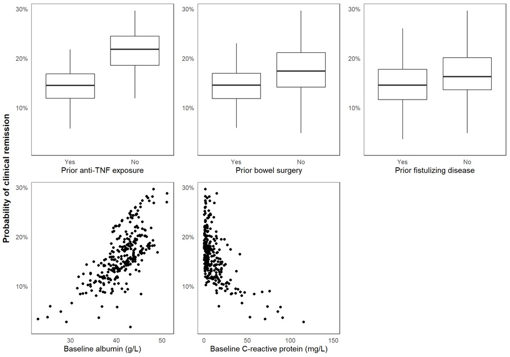

```r
vdz_cd_mvassociations_df$no_previous_antitnf <- fct_recode(as.character(vdz_cd_mvassociations_df$no_previous_antitnf), "Yes" = "0", "No" = "1")
vdz_cd_mvassociations_df$no_surgery_before <- fct_recode(as.character(vdz_cd_mvassociations_df$no_surgery_before), "Yes" = "0", "No" = "1")
vdz_cd_mvassociations_df$no_fistulizing_before <- fct_recode(as.character(vdz_cd_mvassociations_df$no_fistulizing_before), "Yes" = "0", "No" = "1")

vdz_cd_mv_antitnf <- ggplot2::ggplot(data = vdz_cd_mvassociations_df, aes(x = no_previous_antitnf, y = probs)) +
  geom_boxplot(outlier.shape = NA) +
  ylab("Probability of clinical remission") +
  xlab("Prior anti-TNF exposure") +
  scale_y_continuous(breaks = seq(0, 1, 0.1), labels = scales::percent_format(accuracy = 1)) +
  theme_bw() +
  theme(panel.grid = element_blank(),
        axis.ticks = element_blank(),
        axis.title.y = element_blank())


vdz_cd_mv_surgery <- ggplot2::ggplot(data = vdz_cd_mvassociations_df, aes(x = no_surgery_before, y = probs)) +
  geom_boxplot(outlier.shape = NA) +
  ylab("Probability of clinical remission") +
  xlab("Prior bowel surgery") +
  scale_y_continuous(breaks = seq(0, 1, 0.1), labels = scales::percent_format(accuracy = 1)) +
  theme_bw() +
  theme(panel.grid = element_blank(),
        axis.ticks = element_blank(),
        axis.title.y = element_blank())


vdz_cd_mv_fistulizing <- ggplot2::ggplot(data = vdz_cd_mvassociations_df, aes(x = no_fistulizing_before, y = probs)) +
  geom_boxplot(outlier.shape = NA) +
  ylab("Probability of clinical remission") +
  xlab("Prior fistulizing disease") +
  scale_y_continuous(breaks = seq(0, 1, 0.1), labels = scales::percent_format(accuracy = 1)) +
  theme_bw() +
  theme(panel.grid = element_blank(),
        axis.ticks = element_blank(),
        axis.title.y = element_blank())


vdz_cd_mv_albumin <- ggplot2::ggplot(data = vdz_cd_mvassociations_df, aes(x = albumin_g_L, y = probs)) +
  geom_point() +
  ylab("Probability of clinical remission") +
  xlab("Baseline albumin (g/L)") +
  scale_y_continuous(breaks = seq(0, 1, 0.1), labels = scales::percent_format(accuracy = 1)) +
  theme_bw() +
  theme(panel.grid = element_blank(),
        axis.ticks = element_blank(),
        axis.title.y = element_blank())


vdz_cd_mv_crp <- ggplot2::ggplot(data = vdz_cd_mvassociations_df, aes(x = crp_mg_L, y = probs)) +
  geom_point() +
  ylab("Probability of clinical remission") +
  xlab("Baseline C-reactive protein (mg/L)") +
  scale_y_continuous(breaks = seq(0, 1, 0.1), labels = scales::percent_format(accuracy = 1)) +
  theme_bw() +
  theme(panel.grid = element_blank(),
        axis.ticks = element_blank(),
        axis.title.y = element_blank()) +
  coord_cartesian(xlim = c(0, 150))

vdz_cd_mv_combined <- ggarrange(vdz_cd_mv_antitnf, vdz_cd_mv_surgery, vdz_cd_mv_fistulizing, vdz_cd_mv_albumin, vdz_cd_mv_crp)

annotate_figure(vdz_cd_mv_combined, left = text_grob("Probability of clinical remission", face = "bold", rot = 90))
```

#### VDZ-UC

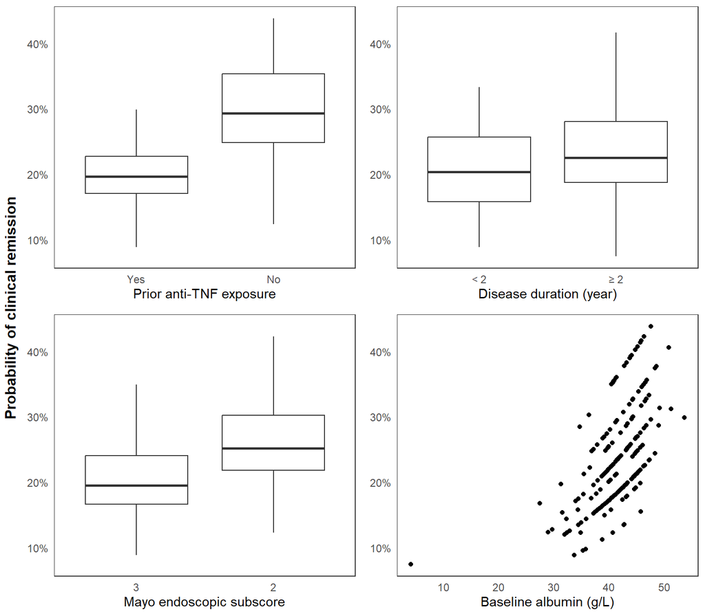

```r
vdz_uc_mvassociations_df$no_previous_antitnf <- fct_recode(as.character(vdz_uc_mvassociations_df$no_previous_antitnf), "Yes" = "0", "No" = "1")
vdz_uc_mvassociations_df$dxduration_above_two <- fct_recode(as.character(vdz_uc_mvassociations_df$dxduration_above_two), "< 2" = "0", "≥ 2" = "1")
vdz_uc_mvassociations_df$moderate_endo_activity <- fct_recode(as.character(vdz_uc_mvassociations_df$moderate_endo_activity), "3" = "0", "2" = "1")

vdz_uc_mv_antitnf <- ggplot2::ggplot(data = vdz_uc_mvassociations_df, aes(x = no_previous_antitnf, y = probs)) +
  geom_boxplot(outlier.shape = NA) +
  ylab("Probability of clinical remission") +
  xlab("Prior anti-TNF exposure") +
  scale_y_continuous(breaks = seq(0, 1, 0.1), labels = scales::percent_format(accuracy = 1)) +
  theme_bw() +
  theme(panel.grid = element_blank(),
        axis.ticks = element_blank(),
        axis.title.y = element_blank())

vdz_uc_mv_duration <- ggplot2::ggplot(data = vdz_uc_mvassociations_df, aes(x = dxduration_above_two, y = probs)) +
  geom_boxplot(outlier.shape = NA) +
  ylab("Probability of clinical remission") +
  xlab("Disease duration (year)") +
  scale_y_continuous(breaks = seq(0, 1, 0.1), labels = scales::percent_format(accuracy = 1)) +
  theme_bw() +
  theme(panel.grid = element_blank(),
        axis.ticks = element_blank(),
        axis.title.y = element_blank())

vdz_uc_mv_endo <- ggplot2::ggplot(data = vdz_uc_mvassociations_df, aes(x = moderate_endo_activity, y = probs)) +
  geom_boxplot(outlier.shape = NA) +
  ylab("Probability of clinical remission") +
  xlab("Mayo endoscopic subscore") +
  scale_y_continuous(breaks = seq(0, 1, 0.1), labels = scales::percent_format(accuracy = 1)) +
  theme_bw() +
  theme(panel.grid = element_blank(),
        axis.ticks = element_blank(),
        axis.title.y = element_blank())

vdz_uc_mv_albumin <- ggplot2::ggplot(data = vdz_uc_mvassociations_df, aes(x = albumin_g_L, y = probs)) +
  geom_point() +
  ylab("Probability of clinical remission") +
  xlab("Baseline albumin (g/L)") +
  scale_y_continuous(breaks = seq(0, 1, 0.1), labels = scales::percent_format(accuracy = 1)) +
  theme_bw() +
  theme(panel.grid = element_blank(),
        axis.ticks = element_blank(),
        axis.title.y = element_blank())

vdz_uc_mv_combined <- ggarrange(vdz_uc_mv_antitnf, vdz_uc_mv_duration, vdz_uc_mv_endo, vdz_uc_mv_albumin)

annotate_figure(vdz_uc_mv_combined, left = text_grob("Probability of clinical remission", face = "bold", rot = 90))
```

#### UST-CD

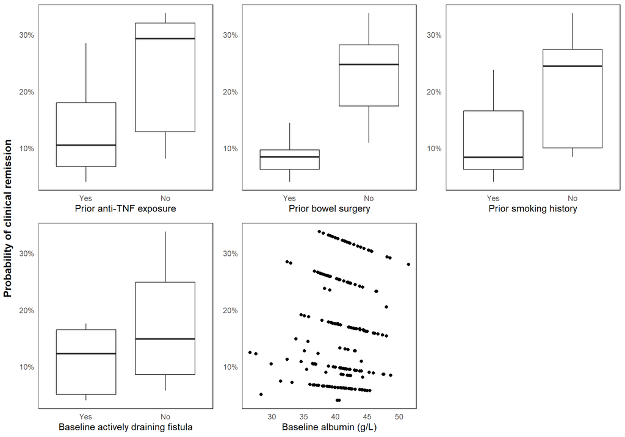

```r
ust_cd_mvassociations_df$no_previous_antitnf <- fct_recode(as.character(ust_cd_mvassociations_df$no_previous_antitnf), "Yes" = "0", "No" = "1")
ust_cd_mvassociations_df$no_surgery_before <- fct_recode(as.character(ust_cd_mvassociations_df$no_surgery_before), "Yes" = "0", "No" = "1")
ust_cd_mvassociations_df$no_prior_smoking <- fct_recode(as.character(ust_cd_mvassociations_df$no_prior_smoking), "Yes" = "0", "No" = "1")
ust_cd_mvassociations_df$no_fistulizing_current <- fct_recode(as.character(ust_cd_mvassociations_df$no_fistulizing_current), "Yes" = "0", "No" = "1")

ust_cd_mv_antitnf <- ggplot2::ggplot(data = ust_cd_mvassociations_df, aes(x = no_previous_antitnf, y = probs)) +
  geom_boxplot(outlier.shape = NA) +
  ylab("Probability of clinical remission") +
  xlab("Prior anti-TNF exposure") +
  scale_y_continuous(breaks = seq(0, 1, 0.1), labels = scales::percent_format(accuracy = 1)) +
  theme_bw() +
  theme(panel.grid = element_blank(),
        axis.ticks = element_blank(),
        axis.title.y = element_blank())


ust_cd_mv_surgery <- ggplot2::ggplot(data = ust_cd_mvassociations_df, aes(x = no_surgery_before, y = probs)) +
  geom_boxplot(outlier.shape = NA) +
  ylab("Probability of clinical remission") +
  xlab("Prior bowel surgery") +
  scale_y_continuous(breaks = seq(0, 1, 0.1), labels = scales::percent_format(accuracy = 1)) +
  theme_bw() +
  theme(panel.grid = element_blank(),
        axis.ticks = element_blank(),
        axis.title.y = element_blank())


ust_cd_mv_smoking <- ggplot2::ggplot(data = ust_cd_mvassociations_df, aes(x = no_prior_smoking, y = probs)) +
  geom_boxplot(outlier.shape = NA) +
  ylab("Probability of clinical remission") +
  xlab("Prior smoking history") +
  scale_y_continuous(breaks = seq(0, 1, 0.1), labels = scales::percent_format(accuracy = 1)) +
  theme_bw() +
  theme(panel.grid = element_blank(),
        axis.ticks = element_blank(),
        axis.title.y = element_blank())

ust_cd_mv_fistulizing <- ggplot2::ggplot(data = ust_cd_mvassociations_df, aes(x = no_fistulizing_current, y = probs)) +
  geom_boxplot(outlier.shape = NA) +
  ylab("Probability of clinical remission") +
  xlab("Baseline actively draining fistula") +
  scale_y_continuous(breaks = seq(0, 1, 0.1), labels = scales::percent_format(accuracy = 1)) +
  theme_bw() +
  theme(panel.grid = element_blank(),
        axis.ticks = element_blank(),
        axis.title.y = element_blank())


ust_cd_mv_albumin <- ggplot2::ggplot(data = ust_cd_mvassociations_df, aes(x = albumin_g_L, y = probs)) +
  geom_point() +
  ylab("Probability of clinical remission") +
  xlab("Baseline albumin (g/L)") +
  scale_y_continuous(breaks = seq(0, 1, 0.1), labels = scales::percent_format(accuracy = 1)) +
  theme_bw() +
  theme(panel.grid = element_blank(),
        axis.ticks = element_blank(),
        axis.title.y = element_blank())

ust_cd_mv_combined <- ggarrange(ust_cd_mv_antitnf, ust_cd_mv_surgery, ust_cd_mv_smoking, ust_cd_mv_fistulizing, ust_cd_mv_albumin)

annotate_figure(ust_cd_mv_combined, left = text_grob("Probability of clinical remission", face = "bold", rot = 90))
```

## 15. Check linearity assumption for numeric variables

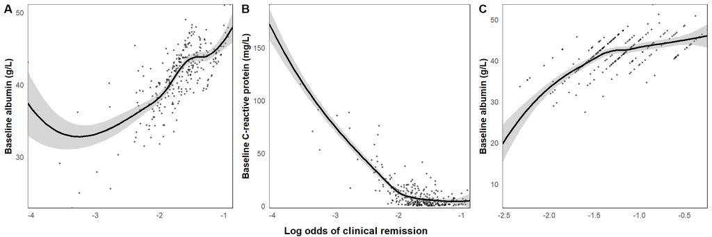

```r
linearity_albumin <- ggplot(vdz_cd_mvassociations_df, aes(logit, albumin_g_L))+
  geom_point(size = 0.5, alpha = 0.5) +
  geom_smooth(method = "loess", col = "black") +
  ylab("Baseline albumin (g/L)") +
  theme_bw() +
  theme(panel.grid = element_blank(),
        axis.ticks = element_blank(),
        axis.title.x = element_blank(),
        axis.title.y = element_text(face = "bold")) +
  coord_cartesian(expand = 0)

linearity_crp <- ggplot(vdz_cd_mvassociations_df, aes(logit, crp_mg_L))+
  geom_point(size = 0.5, alpha = 0.5) +
  geom_smooth(method = "loess", col = "black") +
  ylab("Baseline C-reactive protein (mg/L)") +
  theme_bw() +
  theme(panel.grid = element_blank(),
        axis.ticks = element_blank(),
        axis.title.x = element_blank(),
        axis.title.y = element_text(face = "bold")) +
  coord_cartesian(expand = 0)

linearity_albumin_uc <- ggplot(vdz_uc_mvassociations_df, aes(logit, albumin_g_L))+
  geom_point(size = 0.5, alpha = 0.5) +
  geom_smooth(method = "loess", col = "black") +
  ylab("Baseline albumin (g/L)") +
  theme_bw() +
  theme(panel.grid = element_blank(),
        axis.ticks = element_blank(),
        axis.title.x = element_blank(),
        axis.title.y = element_text(face = "bold")) +
  coord_cartesian(expand = 0)

linearity_combined <- ggarrange(linearity_albumin, linearity_crp, linearity_albumin_uc, labels = c("A", "B", "C"), nrow = 1)

annotate_figure(linearity_combined, bottom = text_grob("Log odds of clinical remission", face = "bold"))
```